# Cyclistic_bike_share_case_study

Iuliia

2022-07-03

# Cyclistic case study

**Data Analyst:** Iuliia Rytck **Client:** Cyclistic **Purpose:** The purpose of this project is to maximize the number of annual members that will be the key to the future growth of Cyclistic.

#### Introduction

You are looking at the Cyclistic bike-share marketing analysis project! This is my first case study of Google’s Data Analytics Professional Certificate program. I will perform real-world tasks as a junior data analyst working in the marketing analyst team for a fictional company Cyclistic, a bike-share company in Chicago. The case study requires to follow the steps of the data analysis process: ask, prepare, process, analyse, share, and act.

#### Scope of Work

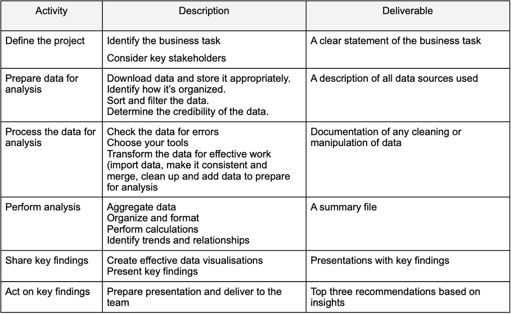

## Step 1 - Define the project

The main goal of this analysis is to design a new marketing strategies to convert casual riders into annual members. In order to achieve this goal the marketing analyst team needs to answer the following questions: –How do annual members and casual riders use Cyclistic bikes differently? –Why would casual riders buy Cyclistic annual memberships? –How can Cyclistic use digital media to influence casual riders to become members?

As a junior data analyst my job is to provide marketing analyst team with insights on how differ annual members and casual riders in use Cyclistic bikes.

#### Statement of the business task: Maximise the number of annual members.

How do annual members and casual riders use Cyclistic bikes differently? Stakeholders: Primary stakeholders: Marketing director  
Primary stakeholders: “Cyclistic” marketing analyst team Secondary stakeholders: “Cyclistic” executive team.

## Step 2 - Prepare data for analysis

To analyze and identify trends, historical trip data were used from Lyft Bikes and Scooters, LLC (“Bikeshare”) that operates the City of Chicago’s Divvy bicycle sharing service. For this analysis I downloaded data from January 2021 to December 2021. 12 months of Cyclistiic trip data were downloaded [here](https://divvy-tripdata.s3.amazonaws.com/index.html)

(Note: The datasets have a different name because Cyclistic is a fictional company. For the purposes of this case study, the datasets are appropriate and will enable to answer the business questions.

The data has been made available by Motivate International Inc. under this [license](https://ride.divvybikes.com/data-license-agreement).)

## Step 3 - Process data for the analysis

Given the big-scale of the datasets, I will use R through RStudio with libraries necessary for manipulation and visualisation.

#### Install packages

```r
library(tidyverse)
library(lubridate)
library(ggplot2)
library(readr)
library(ggmap)
library(geosphere)
```

```r
setwd("/Users/user/Desktop/RStudio_Projects/")
```

#### Collect data.

Notes: 12 csv format files corresponding to 12 months of data for 2021

```r
January <- read_csv("202101-divvy-tripdata.csv")
```

```r
February <- read_csv("202102-divvy-tripdata.csv")
```

```r
March <- read_csv("202103-divvy-tripdata.csv")
```

```r
April <- read_csv("202104-divvy-tripdata.csv")
```

```r
May <- read_csv("202105-divvy-tripdata.csv")
```

```r
June <- read_csv("202106-divvy-tripdata.csv")
```

```r
July <- read_csv("202107-divvy-tripdata.csv")
```

```r
August <- read_csv("202108-divvy-tripdata.csv")
```

```r
September <- read_csv("202109-divvy-tripdata.csv")
```

```r
October <- read_csv("202110-divvy-tripdata.csv")
```

```r
November <- read_csv("202111-divvy-tripdata.csv")
```

```r
December <- read_csv("202112-divvy-tripdata.csv")
```

### Wrangle data and combine into a single dataframe

#### Check column names, inspect the dataframes and look for incongruencies before merging.

```r
colnames(January)
```

```
##  [1] "ride_id"            "rideable_type"      "started_at"
##  [4] "ended_at"           "start_station_name" "start_station_id"
##  [7] "end_station_name"   "end_station_id"     "start_lat"
## [10] "start_lng"          "end_lat"            "end_lng"
## [13] "member_casual"
```

```r
colnames(February)
```

```
##  [1] "ride_id"            "rideable_type"      "started_at"
##  [4] "ended_at"           "start_station_name" "start_station_id"
##  [7] "end_station_name"   "end_station_id"     "start_lat"
## [10] "start_lng"          "end_lat"            "end_lng"
## [13] "member_casual"
```

```r
colnames(March)
```

```
##  [1] "ride_id"            "rideable_type"      "started_at"
##  [4] "ended_at"           "start_station_name" "start_station_id"
##  [7] "end_station_name"   "end_station_id"     "start_lat"
## [10] "start_lng"          "end_lat"            "end_lng"
## [13] "member_casual"
```

```r
str(January)
```

```
## spec_tbl_df [96,834 × 13] (S3: spec_tbl_df/tbl_df/tbl/data.frame)
##  $ ride_id           : chr [1:96834] "E19E6F1B8D4C42ED" "DC88F20C2C55F27F" "EC45C94683FE3F27" "4FA453A75AE377DB" ...
##  $ rideable_type     : chr [1:96834] "electric_bike" "electric_bike" "electric_bike" "electric_bike" ...
##  $ started_at        : POSIXct[1:96834], format: "2021-01-23 16:14:19" "2021-01-27 18:43:08" ...
##  $ ended_at          : POSIXct[1:96834], format: "2021-01-23 16:24:44" "2021-01-27 18:47:12" ...
##  $ start_station_name: chr [1:96834] "California Ave & Cortez St" "California Ave & Cortez St" "California Ave & Cortez St" "California Ave & Cortez St" ...
##  $ start_station_id  : chr [1:96834] "17660" "17660" "17660" "17660" ...
##  $ end_station_name  : chr [1:96834] NA NA NA NA ...
##  $ end_station_id    : chr [1:96834] NA NA NA NA ...
##  $ start_lat         : num [1:96834] 41.9 41.9 41.9 41.9 41.9 ...
##  $ start_lng         : num [1:96834] -87.7 -87.7 -87.7 -87.7 -87.7 ...
##  $ end_lat           : num [1:96834] 41.9 41.9 41.9 41.9 41.9 ...
##  $ end_lng           : num [1:96834] -87.7 -87.7 -87.7 -87.7 -87.7 ...
##  $ member_casual     : chr [1:96834] "member" "member" "member" "member" ...
##  - attr(*, "spec")=
##   .. cols(
##   ..   ride_id = col_character(),
##   ..   rideable_type = col_character(),
##   ..   started_at = col_datetime(format = ""),
##   ..   ended_at = col_datetime(format = ""),
##   ..   start_station_name = col_character(),
##   ..   start_station_id = col_character(),
##   ..   end_station_name = col_character(),
##   ..   end_station_id = col_character(),
##   ..   start_lat = col_double(),
##   ..   start_lng = col_double(),
##   ..   end_lat = col_double(),
##   ..   end_lng = col_double(),
##   ..   member_casual = col_character()
##   .. )
##  - attr(*, "problems")=<externalptr>
```

```r
str(February)
```

```
## spec_tbl_df [49,622 × 13] (S3: spec_tbl_df/tbl_df/tbl/data.frame)
##  $ ride_id           : chr [1:49622] "89E7AA6C29227EFF" "0FEFDE2603568365" "E6159D746B2DBB91" "B32D3199F1C2E75B" ...
##  $ rideable_type     : chr [1:49622] "classic_bike" "classic_bike" "electric_bike" "classic_bike" ...
##  $ started_at        : POSIXct[1:49622], format: "2021-02-12 16:14:56" "2021-02-14 17:52:38" ...
##  $ ended_at          : POSIXct[1:49622], format: "2021-02-12 16:21:43" "2021-02-14 18:12:09" ...
##  $ start_station_name: chr [1:49622] "Glenwood Ave & Touhy Ave" "Glenwood Ave & Touhy Ave" "Clark St & Lake St" "Wood St & Chicago Ave" ...
##  $ start_station_id  : chr [1:49622] "525" "525" "KA1503000012" "637" ...
##  $ end_station_name  : chr [1:49622] "Sheridan Rd & Columbia Ave" "Bosworth Ave & Howard St" "State St & Randolph St" "Honore St & Division St" ...
##  $ end_station_id    : chr [1:49622] "660" "16806" "TA1305000029" "TA1305000034" ...
##  $ start_lat         : num [1:49622] 42 42 41.9 41.9 41.8 ...
##  $ start_lng         : num [1:49622] -87.7 -87.7 -87.6 -87.7 -87.6 ...
##  $ end_lat           : num [1:49622] 42 42 41.9 41.9 41.8 ...
##  $ end_lng           : num [1:49622] -87.7 -87.7 -87.6 -87.7 -87.6 ...
##  $ member_casual     : chr [1:49622] "member" "casual" "member" "member" ...
##  - attr(*, "spec")=
##   .. cols(
##   ..   ride_id = col_character(),
##   ..   rideable_type = col_character(),
##   ..   started_at = col_datetime(format = ""),
##   ..   ended_at = col_datetime(format = ""),
##   ..   start_station_name = col_character(),
##   ..   start_station_id = col_character(),
##   ..   end_station_name = col_character(),
##   ..   end_station_id = col_character(),
##   ..   start_lat = col_double(),
##   ..   start_lng = col_double(),
##   ..   end_lat = col_double(),
##   ..   end_lng = col_double(),
##   ..   member_casual = col_character()
##   .. )
##  - attr(*, "problems")=<externalptr>
```

```r
str(March)
```

```
## spec_tbl_df [228,496 × 13] (S3: spec_tbl_df/tbl_df/tbl/data.frame)
##  $ ride_id           : chr [1:228496] "CFA86D4455AA1030" "30D9DC61227D1AF3" "846D87A15682A284" "994D05AA75A168F2" ...
##  $ rideable_type     : chr [1:228496] "classic_bike" "classic_bike" "classic_bike" "classic_bike" ...
##  $ started_at        : POSIXct[1:228496], format: "2021-03-16 08:32:30" "2021-03-28 01:26:28" ...
##  $ ended_at          : POSIXct[1:228496], format: "2021-03-16 08:36:34" "2021-03-28 01:36:55" ...
##  $ start_station_name: chr [1:228496] "Humboldt Blvd & Armitage Ave" "Humboldt Blvd & Armitage Ave" "Shields Ave & 28th Pl" "Winthrop Ave & Lawrence Ave" ...
##  $ start_station_id  : chr [1:228496] "15651" "15651" "15443" "TA1308000021" ...
##  $ end_station_name  : chr [1:228496] "Stave St & Armitage Ave" "Central Park Ave & Bloomingdale Ave" "Halsted St & 35th St" "Broadway & Sheridan Rd" ...
##  $ end_station_id    : chr [1:228496] "13266" "18017" "TA1308000043" "13323" ...
##  $ start_lat         : num [1:228496] 41.9 41.9 41.8 42 42 ...
##  $ start_lng         : num [1:228496] -87.7 -87.7 -87.6 -87.7 -87.7 ...
##  $ end_lat           : num [1:228496] 41.9 41.9 41.8 42 42.1 ...
##  $ end_lng           : num [1:228496] -87.7 -87.7 -87.6 -87.6 -87.7 ...
##  $ member_casual     : chr [1:228496] "casual" "casual" "casual" "casual" ...
##  - attr(*, "spec")=
##   .. cols(
##   ..   ride_id = col_character(),
##   ..   rideable_type = col_character(),
##   ..   started_at = col_datetime(format = ""),
##   ..   ended_at = col_datetime(format = ""),
##   ..   start_station_name = col_character(),
##   ..   start_station_id = col_character(),
##   ..   end_station_name = col_character(),
##   ..   end_station_id = col_character(),
##   ..   start_lat = col_double(),
##   ..   start_lng = col_double(),
##   ..   end_lat = col_double(),
##   ..   end_lng = col_double(),
##   ..   member_casual = col_character()
##   .. )
##  - attr(*, "problems")=<externalptr>
```

```r
Quarter_1_2021_tripdata <- bind_rows(January, February, March)
```

```r
colnames(April)
```

```
##  [1] "ride_id"            "rideable_type"      "started_at"
##  [4] "ended_at"           "start_station_name" "start_station_id"
##  [7] "end_station_name"   "end_station_id"     "start_lat"
## [10] "start_lng"          "end_lat"            "end_lng"
## [13] "member_casual"
```

```r
colnames(May)
```

```
##  [1] "ride_id"            "rideable_type"      "started_at"
##  [4] "ended_at"           "start_station_name" "start_station_id"
##  [7] "end_station_name"   "end_station_id"     "start_lat"
## [10] "start_lng"          "end_lat"            "end_lng"
## [13] "member_casual"
```

```r
colnames(June)
```

```
##  [1] "ride_id"            "rideable_type"      "started_at"
##  [4] "ended_at"           "start_station_name" "start_station_id"
##  [7] "end_station_name"   "end_station_id"     "start_lat"
## [10] "start_lng"          "end_lat"            "end_lng"
## [13] "member_casual"
```

```r
str(April)
```

```
## spec_tbl_df [337,230 × 13] (S3: spec_tbl_df/tbl_df/tbl/data.frame)
##  $ ride_id           : chr [1:337230] "6C992BD37A98A63F" "1E0145613A209000" "E498E15508A80BAD" "1887262AD101C604" ...
##  $ rideable_type     : chr [1:337230] "classic_bike" "docked_bike" "docked_bike" "classic_bike" ...
##  $ started_at        : POSIXct[1:337230], format: "2021-04-12 18:25:36" "2021-04-27 17:27:11" ...
##  $ ended_at          : POSIXct[1:337230], format: "2021-04-12 18:56:55" "2021-04-27 18:31:29" ...
##  $ start_station_name: chr [1:337230] "State St & Pearson St" "Dorchester Ave & 49th St" "Loomis Blvd & 84th St" "Honore St & Division St" ...
##  $ start_station_id  : chr [1:337230] "TA1307000061" "KA1503000069" "20121" "TA1305000034" ...
##  $ end_station_name  : chr [1:337230] "Southport Ave & Waveland Ave" "Dorchester Ave & 49th St" "Loomis Blvd & 84th St" "Southport Ave & Waveland Ave" ...
##  $ end_station_id    : chr [1:337230] "13235" "KA1503000069" "20121" "13235" ...
##  $ start_lat         : num [1:337230] 41.9 41.8 41.7 41.9 41.7 ...
##  $ start_lng         : num [1:337230] -87.6 -87.6 -87.7 -87.7 -87.7 ...
##  $ end_lat           : num [1:337230] 41.9 41.8 41.7 41.9 41.7 ...
##  $ end_lng           : num [1:337230] -87.7 -87.6 -87.7 -87.7 -87.7 ...
##  $ member_casual     : chr [1:337230] "member" "casual" "casual" "member" ...
##  - attr(*, "spec")=
##   .. cols(
##   ..   ride_id = col_character(),
##   ..   rideable_type = col_character(),
##   ..   started_at = col_datetime(format = ""),
##   ..   ended_at = col_datetime(format = ""),
##   ..   start_station_name = col_character(),
##   ..   start_station_id = col_character(),
##   ..   end_station_name = col_character(),
##   ..   end_station_id = col_character(),
##   ..   start_lat = col_double(),
##   ..   start_lng = col_double(),
##   ..   end_lat = col_double(),
##   ..   end_lng = col_double(),
##   ..   member_casual = col_character()
##   .. )
##  - attr(*, "problems")=<externalptr>
```

```r
str(May)
```

```
## spec_tbl_df [531,633 × 13] (S3: spec_tbl_df/tbl_df/tbl/data.frame)
##  $ ride_id           : chr [1:531633] "C809ED75D6160B2A" "DD59FDCE0ACACAF3" "0AB83CB88C43EFC2" "7881AC6D39110C60" ...
##  $ rideable_type     : chr [1:531633] "electric_bike" "electric_bike" "electric_bike" "electric_bike" ...
##  $ started_at        : POSIXct[1:531633], format: "2021-05-30 11:58:15" "2021-05-30 11:29:14" ...
##  $ ended_at          : POSIXct[1:531633], format: "2021-05-30 12:10:39" "2021-05-30 12:14:09" ...
##  $ start_station_name: chr [1:531633] NA NA NA NA ...
##  $ start_station_id  : chr [1:531633] NA NA NA NA ...
##  $ end_station_name  : chr [1:531633] NA NA NA NA ...
##  $ end_station_id    : chr [1:531633] NA NA NA NA ...
##  $ start_lat         : num [1:531633] 41.9 41.9 41.9 41.9 41.9 ...
##  $ start_lng         : num [1:531633] -87.6 -87.6 -87.7 -87.7 -87.7 ...
##  $ end_lat           : num [1:531633] 41.9 41.8 41.9 41.9 41.9 ...
##  $ end_lng           : num [1:531633] -87.6 -87.6 -87.7 -87.7 -87.7 ...
##  $ member_casual     : chr [1:531633] "casual" "casual" "casual" "casual" ...
##  - attr(*, "spec")=
##   .. cols(
##   ..   ride_id = col_character(),
##   ..   rideable_type = col_character(),
##   ..   started_at = col_datetime(format = ""),
##   ..   ended_at = col_datetime(format = ""),
##   ..   start_station_name = col_character(),
##   ..   start_station_id = col_character(),
##   ..   end_station_name = col_character(),
##   ..   end_station_id = col_character(),
##   ..   start_lat = col_double(),
##   ..   start_lng = col_double(),
##   ..   end_lat = col_double(),
##   ..   end_lng = col_double(),
##   ..   member_casual = col_character()
##   .. )
##  - attr(*, "problems")=<externalptr>
```

```r
str(June)
```

```
## spec_tbl_df [729,595 × 13] (S3: spec_tbl_df/tbl_df/tbl/data.frame)
##  $ ride_id           : chr [1:729595] "99FEC93BA843FB20" "06048DCFC8520CAF" "9598066F68045DF2" "B03C0FE48C412214" ...
##  $ rideable_type     : chr [1:729595] "electric_bike" "electric_bike" "electric_bike" "electric_bike" ...
##  $ started_at        : POSIXct[1:729595], format: "2021-06-13 14:31:28" "2021-06-04 11:18:02" ...
##  $ ended_at          : POSIXct[1:729595], format: "2021-06-13 14:34:11" "2021-06-04 11:24:19" ...
##  $ start_station_name: chr [1:729595] NA NA NA NA ...
##  $ start_station_id  : chr [1:729595] NA NA NA NA ...
##  $ end_station_name  : chr [1:729595] NA NA NA NA ...
##  $ end_station_id    : chr [1:729595] NA NA NA NA ...
##  $ start_lat         : num [1:729595] 41.8 41.8 41.8 41.8 41.8 ...
##  $ start_lng         : num [1:729595] -87.6 -87.6 -87.6 -87.6 -87.6 ...
##  $ end_lat           : num [1:729595] 41.8 41.8 41.8 41.8 41.8 ...
##  $ end_lng           : num [1:729595] -87.6 -87.6 -87.6 -87.6 -87.6 ...
##  $ member_casual     : chr [1:729595] "member" "member" "member" "member" ...
##  - attr(*, "spec")=
##   .. cols(
##   ..   ride_id = col_character(),
##   ..   rideable_type = col_character(),
##   ..   started_at = col_datetime(format = ""),
##   ..   ended_at = col_datetime(format = ""),
##   ..   start_station_name = col_character(),
##   ..   start_station_id = col_character(),
##   ..   end_station_name = col_character(),
##   ..   end_station_id = col_character(),
##   ..   start_lat = col_double(),
##   ..   start_lng = col_double(),
##   ..   end_lat = col_double(),
##   ..   end_lng = col_double(),
##   ..   member_casual = col_character()
##   .. )
##  - attr(*, "problems")=<externalptr>
```

```r
Quarter_2_2021_tripdata <- bind_rows(April, May, June)
```

```r
colnames(July)
```

```
##  [1] "ride_id"            "rideable_type"      "started_at"
##  [4] "ended_at"           "start_station_name" "start_station_id"
##  [7] "end_station_name"   "end_station_id"     "start_lat"
## [10] "start_lng"          "end_lat"            "end_lng"
## [13] "member_casual"
```

```r
colnames(August)
```

```
##  [1] "ride_id"            "rideable_type"      "started_at"
##  [4] "ended_at"           "start_station_name" "start_station_id"
##  [7] "end_station_name"   "end_station_id"     "start_lat"
## [10] "start_lng"          "end_lat"            "end_lng"
## [13] "member_casual"
```

```r
colnames(September)
```

```
##  [1] "ride_id"            "rideable_type"      "started_at"
##  [4] "ended_at"           "start_station_name" "start_station_id"
##  [7] "end_station_name"   "end_station_id"     "start_lat"
## [10] "start_lng"          "end_lat"            "end_lng"
## [13] "member_casual"
```

```r
str(July)
```

```
## spec_tbl_df [822,410 × 13] (S3: spec_tbl_df/tbl_df/tbl/data.frame)
##  $ ride_id           : chr [1:822410] "0A1B623926EF4E16" "B2D5583A5A5E76EE" "6F264597DDBF427A" "379B58EAB20E8AA5" ...
##  $ rideable_type     : chr [1:822410] "docked_bike" "classic_bike" "classic_bike" "classic_bike" ...
##  $ started_at        : POSIXct[1:822410], format: "2021-07-02 14:44:36" "2021-07-07 16:57:42" ...
##  $ ended_at          : POSIXct[1:822410], format: "2021-07-02 15:19:58" "2021-07-07 17:16:09" ...
##  $ start_station_name: chr [1:822410] "Michigan Ave & Washington St" "California Ave & Cortez St" "Wabash Ave & 16th St" "California Ave & Cortez St" ...
##  $ start_station_id  : chr [1:822410] "13001" "17660" "SL-012" "17660" ...
##  $ end_station_name  : chr [1:822410] "Halsted St & North Branch St" "Wood St & Hubbard St" "Rush St & Hubbard St" "Carpenter St & Huron St" ...
##  $ end_station_id    : chr [1:822410] "KA1504000117" "13432" "KA1503000044" "13196" ...
##  $ start_lat         : num [1:822410] 41.9 41.9 41.9 41.9 41.9 ...
##  $ start_lng         : num [1:822410] -87.6 -87.7 -87.6 -87.7 -87.7 ...
##  $ end_lat           : num [1:822410] 41.9 41.9 41.9 41.9 41.9 ...
##  $ end_lng           : num [1:822410] -87.6 -87.7 -87.6 -87.7 -87.7 ...
##  $ member_casual     : chr [1:822410] "casual" "casual" "member" "member" ...
##  - attr(*, "spec")=
##   .. cols(
##   ..   ride_id = col_character(),
##   ..   rideable_type = col_character(),
##   ..   started_at = col_datetime(format = ""),
##   ..   ended_at = col_datetime(format = ""),
##   ..   start_station_name = col_character(),
##   ..   start_station_id = col_character(),
##   ..   end_station_name = col_character(),
##   ..   end_station_id = col_character(),
##   ..   start_lat = col_double(),
##   ..   start_lng = col_double(),
##   ..   end_lat = col_double(),
##   ..   end_lng = col_double(),
##   ..   member_casual = col_character()
##   .. )
##  - attr(*, "problems")=<externalptr>
```

```r
str(August)
```

```
## spec_tbl_df [804,352 × 13] (S3: spec_tbl_df/tbl_df/tbl/data.frame)
##  $ ride_id           : chr [1:804352] "99103BB87CC6C1BB" "EAFCCCFB0A3FC5A1" "9EF4F46C57AD234D" "5834D3208BFAF1DA" ...
##  $ rideable_type     : chr [1:804352] "electric_bike" "electric_bike" "electric_bike" "electric_bike" ...
##  $ started_at        : POSIXct[1:804352], format: "2021-08-10 17:15:49" "2021-08-10 17:23:14" ...
##  $ ended_at          : POSIXct[1:804352], format: "2021-08-10 17:22:44" "2021-08-10 17:39:24" ...
##  $ start_station_name: chr [1:804352] NA NA NA NA ...
##  $ start_station_id  : chr [1:804352] NA NA NA NA ...
##  $ end_station_name  : chr [1:804352] NA NA NA NA ...
##  $ end_station_id    : chr [1:804352] NA NA NA NA ...
##  $ start_lat         : num [1:804352] 41.8 41.8 42 42 41.8 ...
##  $ start_lng         : num [1:804352] -87.7 -87.7 -87.7 -87.7 -87.6 ...
##  $ end_lat           : num [1:804352] 41.8 41.8 42 42 41.8 ...
##  $ end_lng           : num [1:804352] -87.7 -87.6 -87.7 -87.7 -87.6 ...
##  $ member_casual     : chr [1:804352] "member" "member" "member" "member" ...
##  - attr(*, "spec")=
##   .. cols(
##   ..   ride_id = col_character(),
##   ..   rideable_type = col_character(),
##   ..   started_at = col_datetime(format = ""),
##   ..   ended_at = col_datetime(format = ""),
##   ..   start_station_name = col_character(),
##   ..   start_station_id = col_character(),
##   ..   end_station_name = col_character(),
##   ..   end_station_id = col_character(),
##   ..   start_lat = col_double(),
##   ..   start_lng = col_double(),
##   ..   end_lat = col_double(),
##   ..   end_lng = col_double(),
##   ..   member_casual = col_character()
##   .. )
##  - attr(*, "problems")=<externalptr>
```

```r
str(September)
```

```
## spec_tbl_df [756,147 × 13] (S3: spec_tbl_df/tbl_df/tbl/data.frame)
##  $ ride_id           : chr [1:756147] "9DC7B962304CBFD8" "F930E2C6872D6B32" "6EF72137900BB910" "78D1DE133B3DBF55" ...
##  $ rideable_type     : chr [1:756147] "electric_bike" "electric_bike" "electric_bike" "electric_bike" ...
##  $ started_at        : POSIXct[1:756147], format: "2021-09-28 16:07:10" "2021-09-28 14:24:51" ...
##  $ ended_at          : POSIXct[1:756147], format: "2021-09-28 16:09:54" "2021-09-28 14:40:05" ...
##  $ start_station_name: chr [1:756147] NA NA NA NA ...
##  $ start_station_id  : chr [1:756147] NA NA NA NA ...
##  $ end_station_name  : chr [1:756147] NA NA NA NA ...
##  $ end_station_id    : chr [1:756147] NA NA NA NA ...
##  $ start_lat         : num [1:756147] 41.9 41.9 41.8 41.8 41.9 ...
##  $ start_lng         : num [1:756147] -87.7 -87.6 -87.7 -87.7 -87.7 ...
##  $ end_lat           : num [1:756147] 41.9 42 41.8 41.8 41.9 ...
##  $ end_lng           : num [1:756147] -87.7 -87.7 -87.7 -87.7 -87.7 ...
##  $ member_casual     : chr [1:756147] "casual" "casual" "casual" "casual" ...
##  - attr(*, "spec")=
##   .. cols(
##   ..   ride_id = col_character(),
##   ..   rideable_type = col_character(),
##   ..   started_at = col_datetime(format = ""),
##   ..   ended_at = col_datetime(format = ""),
##   ..   start_station_name = col_character(),
##   ..   start_station_id = col_character(),
##   ..   end_station_name = col_character(),
##   ..   end_station_id = col_character(),
##   ..   start_lat = col_double(),
##   ..   start_lng = col_double(),
##   ..   end_lat = col_double(),
##   ..   end_lng = col_double(),
##   ..   member_casual = col_character()
##   .. )
##  - attr(*, "problems")=<externalptr>
```

```r
Quarter_3_2021_tripdata <- bind_rows(July, August, September)
```

```r
colnames(October)
```

```
##  [1] "ride_id"            "rideable_type"      "started_at"
##  [4] "ended_at"           "start_station_name" "start_station_id"
##  [7] "end_station_name"   "end_station_id"     "start_lat"
## [10] "start_lng"          "end_lat"            "end_lng"
## [13] "member_casual"
```

```r
colnames(November)
```

```
##  [1] "ride_id"            "rideable_type"      "started_at"
##  [4] "ended_at"           "start_station_name" "start_station_id"
##  [7] "end_station_name"   "end_station_id"     "start_lat"
## [10] "start_lng"          "end_lat"            "end_lng"
## [13] "member_casual"
```

```r
colnames(December)
```

```
##  [1] "ride_id"            "rideable_type"      "started_at"
##  [4] "ended_at"           "start_station_name" "start_station_id"
##  [7] "end_station_name"   "end_station_id"     "start_lat"
## [10] "start_lng"          "end_lat"            "end_lng"
## [13] "member_casual"
```

```r
str(October)
```

```
## spec_tbl_df [631,226 × 13] (S3: spec_tbl_df/tbl_df/tbl/data.frame)
##  $ ride_id           : chr [1:631226] "620BC6107255BF4C" "4471C70731AB2E45" "26CA69D43D15EE14" "362947F0437E1514" ...
##  $ rideable_type     : chr [1:631226] "electric_bike" "electric_bike" "electric_bike" "electric_bike" ...
##  $ started_at        : POSIXct[1:631226], format: "2021-10-22 12:46:42" "2021-10-21 09:12:37" ...
##  $ ended_at          : POSIXct[1:631226], format: "2021-10-22 12:49:50" "2021-10-21 09:14:14" ...
##  $ start_station_name: chr [1:631226] "Kingsbury St & Kinzie St" NA NA NA ...
##  $ start_station_id  : chr [1:631226] "KA1503000043" NA NA NA ...
##  $ end_station_name  : chr [1:631226] NA NA NA NA ...
##  $ end_station_id    : chr [1:631226] NA NA NA NA ...
##  $ start_lat         : num [1:631226] 41.9 41.9 41.9 41.9 41.9 ...
##  $ start_lng         : num [1:631226] -87.6 -87.7 -87.7 -87.7 -87.7 ...
##  $ end_lat           : num [1:631226] 41.9 41.9 41.9 41.9 41.9 ...
##  $ end_lng           : num [1:631226] -87.6 -87.7 -87.7 -87.7 -87.7 ...
##  $ member_casual     : chr [1:631226] "member" "member" "member" "member" ...
##  - attr(*, "spec")=
##   .. cols(
##   ..   ride_id = col_character(),
##   ..   rideable_type = col_character(),
##   ..   started_at = col_datetime(format = ""),
##   ..   ended_at = col_datetime(format = ""),
##   ..   start_station_name = col_character(),
##   ..   start_station_id = col_character(),
##   ..   end_station_name = col_character(),
##   ..   end_station_id = col_character(),
##   ..   start_lat = col_double(),
##   ..   start_lng = col_double(),
##   ..   end_lat = col_double(),
##   ..   end_lng = col_double(),
##   ..   member_casual = col_character()
##   .. )
##  - attr(*, "problems")=<externalptr>
```

```r
str(November)
```

```
## spec_tbl_df [359,978 × 13] (S3: spec_tbl_df/tbl_df/tbl/data.frame)
##  $ ride_id           : chr [1:359978] "7C00A93E10556E47" "90854840DFD508BA" "0A7D10CDD144061C" "2F3BE33085BCFF02" ...
##  $ rideable_type     : chr [1:359978] "electric_bike" "electric_bike" "electric_bike" "electric_bike" ...
##  $ started_at        : POSIXct[1:359978], format: "2021-11-27 13:27:38" "2021-11-27 13:38:25" ...
##  $ ended_at          : POSIXct[1:359978], format: "2021-11-27 13:46:38" "2021-11-27 13:56:10" ...
##  $ start_station_name: chr [1:359978] NA NA NA NA ...
##  $ start_station_id  : chr [1:359978] NA NA NA NA ...
##  $ end_station_name  : chr [1:359978] NA NA NA NA ...
##  $ end_station_id    : chr [1:359978] NA NA NA NA ...
##  $ start_lat         : num [1:359978] 41.9 42 42 41.9 41.9 ...
##  $ start_lng         : num [1:359978] -87.7 -87.7 -87.7 -87.8 -87.6 ...
##  $ end_lat           : num [1:359978] 42 41.9 42 41.9 41.9 ...
##  $ end_lng           : num [1:359978] -87.7 -87.7 -87.7 -87.8 -87.6 ...
##  $ member_casual     : chr [1:359978] "casual" "casual" "casual" "casual" ...
##  - attr(*, "spec")=
##   .. cols(
##   ..   ride_id = col_character(),
##   ..   rideable_type = col_character(),
##   ..   started_at = col_datetime(format = ""),
##   ..   ended_at = col_datetime(format = ""),
##   ..   start_station_name = col_character(),
##   ..   start_station_id = col_character(),
##   ..   end_station_name = col_character(),
##   ..   end_station_id = col_character(),
##   ..   start_lat = col_double(),
##   ..   start_lng = col_double(),
##   ..   end_lat = col_double(),
##   ..   end_lng = col_double(),
##   ..   member_casual = col_character()
##   .. )
##  - attr(*, "problems")=<externalptr>
```

```r
str(December)
```

```
## spec_tbl_df [247,540 × 13] (S3: spec_tbl_df/tbl_df/tbl/data.frame)
##  $ ride_id           : chr [1:247540] "46F8167220E4431F" "73A77762838B32FD" "4CF42452054F59C5" "3278BA87BF698339" ...
##  $ rideable_type     : chr [1:247540] "electric_bike" "electric_bike" "electric_bike" "classic_bike" ...
##  $ started_at        : POSIXct[1:247540], format: "2021-12-07 15:06:07" "2021-12-11 03:43:29" ...
##  $ ended_at          : POSIXct[1:247540], format: "2021-12-07 15:13:42" "2021-12-11 04:10:23" ...
##  $ start_station_name: chr [1:247540] "Laflin St & Cullerton St" "LaSalle Dr & Huron St" "Halsted St & North Branch St" "Halsted St & North Branch St" ...
##  $ start_station_id  : chr [1:247540] "13307" "KP1705001026" "KA1504000117" "KA1504000117" ...
##  $ end_station_name  : chr [1:247540] "Morgan St & Polk St" "Clarendon Ave & Leland Ave" "Broadway & Barry Ave" "LaSalle Dr & Huron St" ...
##  $ end_station_id    : chr [1:247540] "TA1307000130" "TA1307000119" "13137" "KP1705001026" ...
##  $ start_lat         : num [1:247540] 41.9 41.9 41.9 41.9 41.9 ...
##  $ start_lng         : num [1:247540] -87.7 -87.6 -87.6 -87.6 -87.7 ...
##  $ end_lat           : num [1:247540] 41.9 42 41.9 41.9 41.9 ...
##  $ end_lng           : num [1:247540] -87.7 -87.7 -87.6 -87.6 -87.6 ...
##  $ member_casual     : chr [1:247540] "member" "casual" "member" "member" ...
##  - attr(*, "spec")=
##   .. cols(
##   ..   ride_id = col_character(),
##   ..   rideable_type = col_character(),
##   ..   started_at = col_datetime(format = ""),
##   ..   ended_at = col_datetime(format = ""),
##   ..   start_station_name = col_character(),
##   ..   start_station_id = col_character(),
##   ..   end_station_name = col_character(),
##   ..   end_station_id = col_character(),
##   ..   start_lat = col_double(),
##   ..   start_lng = col_double(),
##   ..   end_lat = col_double(),
##   ..   end_lng = col_double(),
##   ..   member_casual = col_character()
##   .. )
##  - attr(*, "problems")=<externalptr>
```

```r
Quarter_4_2021_tripdata <- bind_rows(October, November, December)
```

```r
glimpse(Quarter_1_2021_tripdata)
```

```
## Rows: 374,952
## Columns: 13
## $ ride_id            <chr> "E19E6F1B8D4C42ED", "DC88F20C2C55F27F", "EC45C94683…
## $ rideable_type      <chr> "electric_bike", "electric_bike", "electric_bike", …
## $ started_at         <dttm> 2021-01-23 16:14:19, 2021-01-27 18:43:08, 2021-01-…
## $ ended_at           <dttm> 2021-01-23 16:24:44, 2021-01-27 18:47:12, 2021-01-…
## $ start_station_name <chr> "California Ave & Cortez St", "California Ave & Cor…
## $ start_station_id   <chr> "17660", "17660", "17660", "17660", "17660", "17660…
## $ end_station_name   <chr> NA, NA, NA, NA, NA, NA, NA, NA, NA, "Wood St & Augu…
## $ end_station_id     <chr> NA, NA, NA, NA, NA, NA, NA, NA, NA, "657", "13258",…
## $ start_lat          <dbl> 41.90034, 41.90033, 41.90031, 41.90040, 41.90033, 4…
## $ start_lng          <dbl> -87.69674, -87.69671, -87.69664, -87.69666, -87.696…
## $ end_lat            <dbl> 41.89000, 41.90000, 41.90000, 41.92000, 41.90000, 4…
## $ end_lng            <dbl> -87.72000, -87.69000, -87.70000, -87.69000, -87.700…
## $ member_casual      <chr> "member", "member", "member", "member", "casual", "…
```

```r
glimpse(Quarter_2_2021_tripdata)
```

```
## Rows: 1,598,458
## Columns: 13
## $ ride_id            <chr> "6C992BD37A98A63F", "1E0145613A209000", "E498E15508…
## $ rideable_type      <chr> "classic_bike", "docked_bike", "docked_bike", "clas…
## $ started_at         <dttm> 2021-04-12 18:25:36, 2021-04-27 17:27:11, 2021-04-…
## $ ended_at           <dttm> 2021-04-12 18:56:55, 2021-04-27 18:31:29, 2021-04-…
## $ start_station_name <chr> "State St & Pearson St", "Dorchester Ave & 49th St"…
## $ start_station_id   <chr> "TA1307000061", "KA1503000069", "20121", "TA1305000…
## $ end_station_name   <chr> "Southport Ave & Waveland Ave", "Dorchester Ave & 4…
## $ end_station_id     <chr> "13235", "KA1503000069", "20121", "13235", "20121",…
## $ start_lat          <dbl> 41.89745, 41.80577, 41.74149, 41.90312, 41.74149, 4…
## $ start_lng          <dbl> -87.62872, -87.59246, -87.65841, -87.67394, -87.658…
## $ end_lat            <dbl> 41.94815, 41.80577, 41.74149, 41.94815, 41.74149, 4…
## $ end_lng            <dbl> -87.66394, -87.59246, -87.65841, -87.66394, -87.658…
## $ member_casual      <chr> "member", "casual", "casual", "member", "casual", "…
```

```r
glimpse(Quarter_3_2021_tripdata)
```

```
## Rows: 2,382,909
## Columns: 13
## $ ride_id            <chr> "0A1B623926EF4E16", "B2D5583A5A5E76EE", "6F264597DD…
## $ rideable_type      <chr> "docked_bike", "classic_bike", "classic_bike", "cla…
## $ started_at         <dttm> 2021-07-02 14:44:36, 2021-07-07 16:57:42, 2021-07-…
## $ ended_at           <dttm> 2021-07-02 15:19:58, 2021-07-07 17:16:09, 2021-07-…
## $ start_station_name <chr> "Michigan Ave & Washington St", "California Ave & C…
## $ start_station_id   <chr> "13001", "17660", "SL-012", "17660", "17660", "1766…
## $ end_station_name   <chr> "Halsted St & North Branch St", "Wood St & Hubbard …
## $ end_station_id     <chr> "KA1504000117", "13432", "KA1503000044", "13196", "…
## $ start_lat          <dbl> 41.88398, 41.90036, 41.86038, 41.90036, 41.90035, 4…
## $ start_lng          <dbl> -87.62468, -87.69670, -87.62581, -87.69670, -87.696…
## $ end_lat            <dbl> 41.89937, 41.88990, 41.89017, 41.89456, 41.88659, 4…
## $ end_lng            <dbl> -87.64848, -87.67147, -87.62619, -87.65345, -87.658…
## $ member_casual      <chr> "casual", "casual", "member", "member", "casual", "…
```

```r
glimpse(Quarter_4_2021_tripdata)
```

```
## Rows: 1,238,744
## Columns: 13
## $ ride_id            <chr> "620BC6107255BF4C", "4471C70731AB2E45", "26CA69D43D…
## $ rideable_type      <chr> "electric_bike", "electric_bike", "electric_bike", …
## $ started_at         <dttm> 2021-10-22 12:46:42, 2021-10-21 09:12:37, 2021-10-…
## $ ended_at           <dttm> 2021-10-22 12:49:50, 2021-10-21 09:14:14, 2021-10-…
## $ start_station_name <chr> "Kingsbury St & Kinzie St", NA, NA, NA, NA, NA, NA,…
## $ start_station_id   <chr> "KA1503000043", NA, NA, NA, NA, NA, NA, NA, NA, NA,…
## $ end_station_name   <chr> NA, NA, NA, NA, NA, NA, NA, NA, NA, NA, NA, NA, NA,…
## $ end_station_id     <chr> NA, NA, NA, NA, NA, NA, NA, NA, NA, NA, NA, NA, NA,…
## $ start_lat          <dbl> 41.88919, 41.93000, 41.92000, 41.92000, 41.89000, 4…
## $ start_lng          <dbl> -87.63850, -87.70000, -87.70000, -87.69000, -87.710…
## $ end_lat            <dbl> 41.89000, 41.93000, 41.94000, 41.92000, 41.89000, 4…
## $ end_lng            <dbl> -87.63000, -87.71000, -87.72000, -87.69000, -87.690…
## $ member_casual      <chr> "member", "member", "member", "member", "member", "…
```

#### Combine all quarters in one dataframe

```r
Total_2021_tripdata <- bind_rows(Quarter_1_2021_tripdata, Quarter_2_2021_tripdata, Quarter_3_2021_tripdata, Quarter_4_2021_tripdata)
```

```r
glimpse(Total_2021_tripdata, message=FALSE)
```

```
## Rows: 5,595,063
## Columns: 13
## $ ride_id            <chr> "E19E6F1B8D4C42ED", "DC88F20C2C55F27F", "EC45C94683…
## $ rideable_type      <chr> "electric_bike", "electric_bike", "electric_bike", …
## $ started_at         <dttm> 2021-01-23 16:14:19, 2021-01-27 18:43:08, 2021-01-…
## $ ended_at           <dttm> 2021-01-23 16:24:44, 2021-01-27 18:47:12, 2021-01-…
## $ start_station_name <chr> "California Ave & Cortez St", "California Ave & Cor…
## $ start_station_id   <chr> "17660", "17660", "17660", "17660", "17660", "17660…
## $ end_station_name   <chr> NA, NA, NA, NA, NA, NA, NA, NA, NA, "Wood St & Augu…
## $ end_station_id     <chr> NA, NA, NA, NA, NA, NA, NA, NA, NA, "657", "13258",…
## $ start_lat          <dbl> 41.90034, 41.90033, 41.90031, 41.90040, 41.90033, 4…
## $ start_lng          <dbl> -87.69674, -87.69671, -87.69664, -87.69666, -87.696…
## $ end_lat            <dbl> 41.89000, 41.90000, 41.90000, 41.92000, 41.90000, 4…
## $ end_lng            <dbl> -87.72000, -87.69000, -87.70000, -87.69000, -87.700…
## $ member_casual      <chr> "member", "member", "member", "member", "casual", "…
```

### CLEAN UP AND ADD DATA TO PREPARE FOR ANALYSIS

Notes: Clean data. Explore data, looking at the total number of rows, distinct values, maximum, minimum, or mean values. Check for null values and duplicates Check validity of the data range Organize and save cleaned data

#### Inspect new table

```r
dim(Total_2021_tripdata)
```

```
## [1] 5595063      13
```

```r
head(Total_2021_tripdata)
```

```
## # A tibble: 6 × 13
##   ride_id rideable_type started_at          ended_at            start_station_n…
##   <chr>   <chr>         <dttm>              <dttm>              <chr>
## 1 E19E6F… electric_bike 2021-01-23 16:14:19 2021-01-23 16:24:44 California Ave …
## 2 DC88F2… electric_bike 2021-01-27 18:43:08 2021-01-27 18:47:12 California Ave …
## 3 EC45C9… electric_bike 2021-01-21 22:35:54 2021-01-21 22:37:14 California Ave …
## 4 4FA453… electric_bike 2021-01-07 13:31:13 2021-01-07 13:42:55 California Ave …
## 5 BE5E8E… electric_bike 2021-01-23 02:24:02 2021-01-23 02:24:45 California Ave …
## 6 5D8969… electric_bike 2021-01-09 14:24:07 2021-01-09 15:17:54 California Ave …
## # … with 8 more variables: start_station_id <chr>, end_station_name <chr>,
## #   end_station_id <chr>, start_lat <dbl>, start_lng <dbl>, end_lat <dbl>,
## #   end_lng <dbl>, member_casual <chr>
```

```r
str(Total_2021_tripdata)
```

```
## spec_tbl_df [5,595,063 × 13] (S3: spec_tbl_df/tbl_df/tbl/data.frame)
##  $ ride_id           : chr [1:5595063] "E19E6F1B8D4C42ED" "DC88F20C2C55F27F" "EC45C94683FE3F27" "4FA453A75AE377DB" ...
##  $ rideable_type     : chr [1:5595063] "electric_bike" "electric_bike" "electric_bike" "electric_bike" ...
##  $ started_at        : POSIXct[1:5595063], format: "2021-01-23 16:14:19" "2021-01-27 18:43:08" ...
##  $ ended_at          : POSIXct[1:5595063], format: "2021-01-23 16:24:44" "2021-01-27 18:47:12" ...
##  $ start_station_name: chr [1:5595063] "California Ave & Cortez St" "California Ave & Cortez St" "California Ave & Cortez St" "California Ave & Cortez St" ...
##  $ start_station_id  : chr [1:5595063] "17660" "17660" "17660" "17660" ...
##  $ end_station_name  : chr [1:5595063] NA NA NA NA ...
##  $ end_station_id    : chr [1:5595063] NA NA NA NA ...
##  $ start_lat         : num [1:5595063] 41.9 41.9 41.9 41.9 41.9 ...
##  $ start_lng         : num [1:5595063] -87.7 -87.7 -87.7 -87.7 -87.7 ...
##  $ end_lat           : num [1:5595063] 41.9 41.9 41.9 41.9 41.9 ...
##  $ end_lng           : num [1:5595063] -87.7 -87.7 -87.7 -87.7 -87.7 ...
##  $ member_casual     : chr [1:5595063] "member" "member" "member" "member" ...
##  - attr(*, "spec")=
##   .. cols(
##   ..   ride_id = col_character(),
##   ..   rideable_type = col_character(),
##   ..   started_at = col_datetime(format = ""),
##   ..   ended_at = col_datetime(format = ""),
##   ..   start_station_name = col_character(),
##   ..   start_station_id = col_character(),
##   ..   end_station_name = col_character(),
##   ..   end_station_id = col_character(),
##   ..   start_lat = col_double(),
##   ..   start_lng = col_double(),
##   ..   end_lat = col_double(),
##   ..   end_lng = col_double(),
##   ..   member_casual = col_character()
##   .. )
##  - attr(*, "problems")=<externalptr>
```

```r
colSums(is.na(Total_2021_tripdata))
```

```
##            ride_id      rideable_type         started_at           ended_at
##                  0                  0                  0                  0
## start_station_name   start_station_id   end_station_name     end_station_id
##             690809             690806             739170             739170
##          start_lat          start_lng            end_lat            end_lng
##                  0                  0               4771               4771
##      member_casual
##                  0
```

##### Observations

- 690809 missing values for start_station_name and start_station_id;
- No missing values for start_lat and start_lng
- 739170 missing values for end_station_name and end_station_id,
- 4771 missing values for end_lat and end_lng.

#### Remove rows with missing values

```r
Total_2021_tripdata_V1 <- Total_2021_tripdata[complete.cases(Total_2021_tripdata), ]
```

```r
colSums(is.na(Total_2021_tripdata_V1))
```

```
##            ride_id      rideable_type         started_at           ended_at
##                  0                  0                  0                  0
## start_station_name   start_station_id   end_station_name     end_station_id
##                  0                  0                  0                  0
##          start_lat          start_lng            end_lat            end_lng
##                  0                  0                  0                  0
##      member_casual
##                  0
```

```r
length(unique(Total_2021_tripdata_V1$ride_id))
```

```
## [1] 4588302
```

```r
length(unique(Total_2021_tripdata_V1$ride_id)) == nrow(Total_2021_tripdata_V1)
```

```
## [1] TRUE
```

```r
sum(duplicated(Total_2021_tripdata_V1$ride_id))
```

```
## [1] 0
```

##### Observations

- 4.588.302 unique records, no duplicated values

#### Add columns for month, weekday and ride_length for futher analysis

```r
Total_2021_tripdata_V1$month <- format(as.Date(Total_2021_tripdata_V1$started_at), "%B")
Total_2021_tripdata_V1$day_of_week <- format(as.Date(Total_2021_tripdata_V1$started_at), "%A")
Total_2021_tripdata_V1$ride_length <- difftime (Total_2021_tripdata_V1$ended_at, Total_2021_tripdata_V1$started_at, units = "mins")
```

#### Check the consistancy of the categorical values

```r
table(Total_2021_tripdata_V1$member_casual)
```

```
##
##  casual  member
## 2048379 2539923
```

```r
table(Total_2021_tripdata_V1$month)
```

```
##
##     April    August  December  February   January      July      June     March
##    298207    674409    176371     42996     83509    692321    608778    205691
##       May  November   October September
##    450994    255904    477972    621150
```

```r
table(Total_2021_tripdata_V1$day_of_week)
```

```
##
##    Friday    Monday  Saturday    Sunday  Thursday   Tuesday Wednesday
##    655832    575424    825413    715029    597681    603069    615854
```

```r
table(Total_2021_tripdata_V1$rideable_type)
```

```
##
##  classic_bike   docked_bike electric_bike
##       3241988        312049       1034265
```

##### Observations

- Two options for usertype member and casual
- Months are consistent
- Weekdays are consistent
- Three bike types: classic, docked and electric

#### Check validity of the ride duration values

```r
min(Total_2021_tripdata_V1$ride_length)
```

```
## Time difference of -55.9 mins
```

```r
max(Total_2021_tripdata_V1$ride_length)
```

```
## Time difference of 55944.15 mins
```

```r
nrow(Total_2021_tripdata_V1[Total_2021_tripdata_V1$ride_length <= 0,])
```

```
## [1] 198
```

##### Observations

- There are 198 records of negative or “0 sec” ride length, because “started_at” is greater than or equal to the “ended_at”. -The longest ride is 55944.15

#### Remove “bad” data

```r
Total_2021_tripdata_V1 <- Total_2021_tripdata_V1 %>%
  filter(ride_length > 0)
nrow(Total_2021_tripdata_V1[Total_2021_tripdata_V1$ride_length <= 0,])
```

```
## [1] 0
```

##### Check everything as expected

```r
glimpse(Total_2021_tripdata_V1)
```

```
## Rows: 4,588,104
## Columns: 16
## $ ride_id            <chr> "B9F73448DFBE0D45", "457C7F4B5D3DA135", "57C750326F…
## $ rideable_type      <chr> "classic_bike", "electric_bike", "electric_bike", "…
## $ started_at         <dttm> 2021-01-24 19:15:38, 2021-01-23 12:57:38, 2021-01-…
## $ ended_at           <dttm> 2021-01-24 19:22:51, 2021-01-23 13:02:10, 2021-01-…
## $ start_station_name <chr> "California Ave & Cortez St", "California Ave & Cor…
## $ start_station_id   <chr> "17660", "17660", "17660", "17660", "17660", "17660…
## $ end_station_name   <chr> "Wood St & Augusta Blvd", "California Ave & North A…
## $ end_station_id     <chr> "657", "13258", "657", "657", "657", "KA1504000135"…
## $ start_lat          <dbl> 41.90036, 41.90041, 41.90037, 41.90038, 41.90036, 4…
## $ start_lng          <dbl> -87.69670, -87.69673, -87.69669, -87.69672, -87.696…
## $ end_lat            <dbl> 41.89918, 41.91044, 41.89918, 41.89915, 41.89918, 4…
## $ end_lng            <dbl> -87.67220, -87.69689, -87.67218, -87.67218, -87.672…
## $ member_casual      <chr> "member", "member", "casual", "casual", "casual", "…
## $ month              <chr> "January", "January", "January", "January", "Januar…
## $ day_of_week        <chr> "Sunday", "Saturday", "Saturday", "Saturday", "Sund…
## $ ride_length        <drtn> 7.216667 mins, 4.533333 mins, 9.783333 mins, 8.950…
```

##### Observations

- character data type: ride id, rideable type, station names, station ids, usertype, month and dayweek
- Date time: started_at, ended_at
- Double: latitude and longitude
- Difftime: Ride length in minutes

#### Check consistency of the station data

```r
start_station_data <- Total_2021_tripdata_V1 %>%
  select(start_station_name, start_station_id, start_lat, start_lng)
end_station_data <- Total_2021_tripdata_V1 %>%
  select(end_station_name, end_station_id, end_lat, end_lng)
```

#### Inspect start stations data

```r
colSums(is.na(start_station_data))
```

```
## start_station_name   start_station_id          start_lat          start_lng
##                  0                  0                  0                  0
```

```r
start_station_data %>%
  select(start_station_name) %>%
  unique()%>%
  count()
```

```
## # A tibble: 1 × 1
##       n
##   <int>
## 1   842
```

```r
start_station_data %>%
  select(start_station_id) %>%
  unique()%>%
  count()
```

```
## # A tibble: 1 × 1
##       n
##   <int>
## 1   829
```

```r
nchar(start_station_data$start_station_id)%>%
 unique()
```

```
##  [1]  5 12  3  6 10  4  7 35  8  9 36 30
```

```r
nchar(start_station_data$start_lat)%>%
  unique()
```

```
##  [1]  9 16 10  8 14 13  7 15 12  6  5 11  4
```

```r
nchar(start_station_data$start_lng)%>%
  unique()
```

```
##  [1] 10 17 11  9 14  8 13 12 16  6  7  5 15
```

##### Observations

- 842 start station name
- 829 start station ids
- Start_station-id naming is inconsistent, different number of characters
- Coordinates are inconsistent, different number of characters

#### Check end stations data

```r
colSums(is.na(end_station_data))
```

```
## end_station_name   end_station_id          end_lat          end_lng
##                0                0                0                0
```

```r
end_station_data %>%
  select(end_station_name) %>%
  unique()%>%
  count()
```

```
## # A tibble: 1 × 1
##       n
##   <int>
## 1   839
```

```r
end_station_data %>%
  select(end_station_id) %>%
  unique()%>%
  count()
```

```
## # A tibble: 1 × 1
##       n
##   <int>
## 1   827
```

```r
nchar(end_station_data$end_station_id)%>%
 unique()
```

```
##  [1]  3  5 12  6 10  4  7 35  8  9 36 30
```

```r
nchar(end_station_data$end_lat)%>%
  unique()
```

```
##  [1]  9 10 16 14  8 15 13  7 11 12  5  6  4
```

```r
nchar(end_station_data$end_lng)%>%
  unique()
```

```
##  [1]  8 11 17 14 10  9 12  7 13 16  6  5 15
```

##### Observations

Inconsistency in station naming and ids - 839 unique end station name - 827 unique end station ids - Coordinates are inconsistent, different number of characters

#### Let´s find inconsistancies

```r
str(start_station_data)
```

```
## tibble [4,588,104 × 4] (S3: tbl_df/tbl/data.frame)
##  $ start_station_name: chr [1:4588104] "California Ave & Cortez St" "California Ave & Cortez St" "California Ave & Cortez St" "California Ave & Cortez St" ...
##  $ start_station_id  : chr [1:4588104] "17660" "17660" "17660" "17660" ...
##  $ start_lat         : num [1:4588104] 41.9 41.9 41.9 41.9 41.9 ...
##  $ start_lng         : num [1:4588104] -87.7 -87.7 -87.7 -87.7 -87.7 ...
```

```r
str(end_station_data)
```

```
## tibble [4,588,104 × 4] (S3: tbl_df/tbl/data.frame)
##  $ end_station_name: chr [1:4588104] "Wood St & Augusta Blvd" "California Ave & North Ave" "Wood St & Augusta Blvd" "Wood St & Augusta Blvd" ...
##  $ end_station_id  : chr [1:4588104] "657" "13258" "657" "657" ...
##  $ end_lat         : num [1:4588104] 41.9 41.9 41.9 41.9 41.9 ...
##  $ end_lng         : num [1:4588104] -87.7 -87.7 -87.7 -87.7 -87.7 ...
```

```r
start_station_data <- rename(start_station_data,
                             station_name = start_station_name,
                             station_id = start_station_id,
                             latitude = start_lat,
                             longitude = start_lng)
end_station_data <- rename(end_station_data,
                           station_name = end_station_name,
                           station_id = end_station_id,
                           latitude = end_lat,
                           longitude = end_lng)
colnames(start_station_data)
```

```
## [1] "station_name" "station_id"   "latitude"     "longitude"
```

```r
colnames(end_station_data)
```

```
## [1] "station_name" "station_id"   "latitude"     "longitude"
```

#### Merge start station data with end station data

```r
stations_combined <- rbind(start_station_data, end_station_data)
glimpse(stations_combined)
```

```
## Rows: 9,176,208
## Columns: 4
## $ station_name <chr> "California Ave & Cortez St", "California Ave & Cortez St…
## $ station_id   <chr> "17660", "17660", "17660", "17660", "17660", "17660", "17…
## $ latitude     <dbl> 41.90036, 41.90041, 41.90037, 41.90038, 41.90036, 41.9003…
## $ longitude    <dbl> -87.69670, -87.69673, -87.69669, -87.69672, -87.69670, -8…
```

```r
stations_combined <- stations_combined %>%
  unique()
glimpse(stations_combined)
```

```
## Rows: 2,001,139
## Columns: 4
## $ station_name <chr> "California Ave & Cortez St", "California Ave & Cortez St…
## $ station_id   <chr> "17660", "17660", "17660", "17660", "17660", "17660", "17…
## $ latitude     <dbl> 41.90036, 41.90041, 41.90037, 41.90038, 41.90037, 41.9003…
## $ longitude    <dbl> -87.69670, -87.69673, -87.69669, -87.69672, -87.69679, -8…
```

#### Extract station name and ids in a new data frame

```r
id_name <- stations_combined %>%
  select(station_name, station_id)%>%
  arrange(station_id)%>%
  unique()
glimpse(id_name)
```

```
## Rows: 846
## Columns: 2
## $ station_name <chr> "Michigan Ave & Washington St", "LaSalle St & Washington …
## $ station_id   <chr> "13001", "13006", "13008", "13011", "13016", "13017", "13…
```

#### Count unique name and ids

```r
id_name %>% count(station_id)
```

```
## # A tibble: 832 × 2
##    station_id     n
##    <chr>      <int>
##  1 13001          1
##  2 13006          1
##  3 13008          1
##  4 13011          1
##  5 13016          1
##  6 13017          1
##  7 13021          1
##  8 13022          1
##  9 13028          1
## 10 13029          1
## # … with 822 more rows
```

```r
id_name %>% count(station_name)
```

```
## # A tibble: 845 × 2
##    station_name                   n
##    <chr>                      <int>
##  1 2112 W Peterson Ave            1
##  2 351                            1
##  3 63rd St Beach                  1
##  4 900 W Harrison St              1
##  5 Aberdeen St & Jackson Blvd     1
##  6 Aberdeen St & Monroe St        1
##  7 Aberdeen St & Randolph St      1
##  8 Ada St & 113th St              1
##  9 Ada St & Washington Blvd       1
## 10 Adler Planetarium              1
## # … with 835 more rows
```

#### Observations

- 846 unique records
- 845 unique station name
- 832 unique station ids

#### Extract ids

```r
ids <- id_name %>%
  select(station_id)%>%
  count(station_id)
glimpse(ids)
```

```
## Rows: 832
## Columns: 2
## $ station_id <chr> "13001", "13006", "13008", "13011", "13016", "13017", "1302…
## $ n          <int> 1, 1, 1, 1, 1, 1, 1, 1, 1, 1, 1, 1, 1, 1, 1, 1, 1, 1, 1, 1,…
```

#### Filter station ids that appears more than once

```r
filter(ids, n>1)
```

```
## # A tibble: 13 × 2
##    station_id       n
##    <chr>        <int>
##  1 13074            2
##  2 13099            2
##  3 13300            2
##  4 351              2
##  5 631              2
##  6 KA1503000055     2
##  7 KA1504000168     2
##  8 LF-005           2
##  9 TA1305000039     2
## 10 TA1306000029     3
## 11 TA1307000041     2
## 12 TA1309000039     2
## 13 TA1309000049     2
```

##### Observations

- 13th station ids appears more than once

#### Inspect inconsistencies

```r
filter(id_name, station_id == "13074")
```

```
## # A tibble: 2 × 2
##   station_name                                        station_id
##   <chr>                                               <chr>
## 1 Broadway & Wilson Ave                               13074
## 2 Broadway & Wilson - Truman College Vaccination Site 13074
```

```r
filter(id_name, station_id == "13099")
```

```
## # A tibble: 2 × 2
##   station_name                station_id
##   <chr>                       <chr>
## 1 Halsted St & 18th St        13099
## 2 Halsted St & 18th St (Temp) 13099
```

```r
filter(id_name, station_id == "13300")
```

```
## # A tibble: 2 × 2
##   station_name                      station_id
##   <chr>                             <chr>
## 1 Lake Shore Dr & Monroe St         13300
## 2 DuSable Lake Shore Dr & Monroe St 13300
```

```r
filter(id_name, station_id == "351")
```

```
## # A tibble: 2 × 2
##   station_name                  station_id
##   <chr>                         <chr>
## 1 Mulligan Ave & Wellington Ave 351
## 2 351                           351
```

```r
filter(id_name, station_id == "631")
```

```
## # A tibble: 2 × 2
##   station_name                       station_id
##   <chr>                              <chr>
## 1 Malcolm X College                  631
## 2 Malcolm X College Vaccination Site 631
```

```r
filter(id_name, station_id == "KA1503000055")
```

```
## # A tibble: 2 × 2
##   station_name                                   station_id
##   <chr>                                          <chr>
## 1 Halsted St & 63rd St                           KA1503000055
## 2 Halsted & 63rd - Kennedy-King Vaccination Site KA1503000055
```

```r
filter(id_name, station_id == "KA1504000168")
```

```
## # A tibble: 2 × 2
##   station_name                                          station_id
##   <chr>                                                 <chr>
## 1 Western Ave & 28th St                                 KA1504000168
## 2 Western & 28th - Velasquez Institute Vaccination Site KA1504000168
```

```r
filter(id_name, station_id == "LF-005")
```

```
## # A tibble: 2 × 2
##   station_name                       station_id
##   <chr>                              <chr>
## 1 Lake Shore Dr & North Blvd         LF-005
## 2 DuSable Lake Shore Dr & North Blvd LF-005
```

```r
filter(id_name, station_id == "TA1305000039")
```

```
## # A tibble: 2 × 2
##   station_name                 station_id
##   <chr>                        <chr>
## 1 Marshfield Ave & Cortland St TA1305000039
## 2 Elston Ave & Cortland St     TA1305000039
```

```r
filter(id_name, station_id == "TA1306000029")
```

```
## # A tibble: 3 × 2
##   station_name                    station_id
##   <chr>                           <chr>
## 1 Lake Shore Dr & Ohio St         TA1306000029
## 2 DuSable Lake Shore Dr & Ohio St TA1306000029
## 3 McClurg Ct & Ohio St            TA1306000029
```

```r
filter(id_name, station_id == "TA1307000041")
```

```
## # A tibble: 2 × 2
##   station_name                           station_id
##   <chr>                                  <chr>
## 1 Lake Shore Dr & Wellington Ave         TA1307000041
## 2 DuSable Lake Shore Dr & Wellington Ave TA1307000041
```

```r
filter(id_name, station_id == "TA1309000039")
```

```
## # A tibble: 2 × 2
##   station_name                          station_id
##   <chr>                                 <chr>
## 1 Lake Shore Dr & Diversey Pkwy         TA1309000039
## 2 DuSable Lake Shore Dr & Diversey Pkwy TA1309000039
```

```r
filter(id_name, station_id == "TA1309000049")
```

```
## # A tibble: 2 × 2
##   station_name                        station_id
##   <chr>                               <chr>
## 1 Lake Shore Dr & Belmont Ave         TA1309000049
## 2 DuSable Lake Shore Dr & Belmont Ave TA1309000049
```

##### Observations

- For station id “13074”, “13099”, “13300”, “631”, “KA1503000055”, “KA1504000168”, “LF-005”, “TA1307000041”, “TA1309000039”, “TA1309000049” same station has different naming
- For station id “351” station id number entered instead of the name “Mulligan Ave & Wellington Ave”
- Station id “TA1305000039” has two different station name “Marshfield Ave & Cortland St” and “Elston Ave & Cortland St”
- Station id “TA1306000029” the same station has different naming “Lake Shore Dr & Ohio St”  
  “DuSable Lake Shore Dr & Ohio St” and one record has a different station name “McClurg Ct & Ohio St”

#### Lets fix errors in station naming and ids

```r
Total_2021_tripdata_V1 %>%
  filter(start_station_id == "13074", end_station_id == "13074")
```

```
## # A tibble: 508 × 16
##    ride_id          rideable_type started_at          ended_at
##    <chr>            <chr>         <dttm>              <dttm>
##  1 94ADCFC4AA74A9CA classic_bike  2021-01-13 18:03:37 2021-01-13 18:26:42
##  2 58F73DE1970D6FBB classic_bike  2021-02-09 14:40:51 2021-02-09 14:41:10
##  3 A8CB1EBC36BCB3AB classic_bike  2021-02-20 11:09:04 2021-02-20 11:19:46
##  4 E9847D83E83D2457 electric_bike 2021-02-27 15:35:16 2021-02-27 15:35:53
##  5 2993DDF3F5B904B8 classic_bike  2021-02-28 15:21:34 2021-02-28 16:45:24
##  6 9EE013990FF57422 classic_bike  2021-02-19 13:53:19 2021-02-19 13:53:57
##  7 AC93B839DEFA66D9 classic_bike  2021-03-09 12:41:03 2021-03-09 12:41:40
##  8 4571CF6FFA7D9A4D classic_bike  2021-03-21 08:58:55 2021-03-21 08:59:24
##  9 D30A7D925E80BF72 classic_bike  2021-03-13 16:57:00 2021-03-13 17:42:23
## 10 EE2568231E17A5CF classic_bike  2021-03-29 17:37:32 2021-03-29 18:11:50
## # … with 498 more rows, and 12 more variables: start_station_name <chr>,
## #   start_station_id <chr>, end_station_name <chr>, end_station_id <chr>,
## #   start_lat <dbl>, start_lng <dbl>, end_lat <dbl>, end_lng <dbl>,
## #   member_casual <chr>, month <chr>, day_of_week <chr>, ride_length <drtn>
```

```r
Total_2021_tripdata_V1 <- Total_2021_tripdata_V1 %>%
  mutate(start_station_name = replace(start_station_name, start_station_name == "Broadway & Wilson Ave", "Broadway & Wilson - Truman College Vaccination Site"))
Total_2021_tripdata_V1 <- Total_2021_tripdata_V1 %>%
  mutate(end_station_name = replace(end_station_name, end_station_name == "Broadway & Wilson Ave", "Broadway & Wilson - Truman College Vaccination Site"))
  Total_2021_tripdata_V1 %>%
    filter(start_station_id == "13074", end_station_id == "13074")
```

```
## # A tibble: 508 × 16
##    ride_id          rideable_type started_at          ended_at
##    <chr>            <chr>         <dttm>              <dttm>
##  1 94ADCFC4AA74A9CA classic_bike  2021-01-13 18:03:37 2021-01-13 18:26:42
##  2 58F73DE1970D6FBB classic_bike  2021-02-09 14:40:51 2021-02-09 14:41:10
##  3 A8CB1EBC36BCB3AB classic_bike  2021-02-20 11:09:04 2021-02-20 11:19:46
##  4 E9847D83E83D2457 electric_bike 2021-02-27 15:35:16 2021-02-27 15:35:53
##  5 2993DDF3F5B904B8 classic_bike  2021-02-28 15:21:34 2021-02-28 16:45:24
##  6 9EE013990FF57422 classic_bike  2021-02-19 13:53:19 2021-02-19 13:53:57
##  7 AC93B839DEFA66D9 classic_bike  2021-03-09 12:41:03 2021-03-09 12:41:40
##  8 4571CF6FFA7D9A4D classic_bike  2021-03-21 08:58:55 2021-03-21 08:59:24
##  9 D30A7D925E80BF72 classic_bike  2021-03-13 16:57:00 2021-03-13 17:42:23
## 10 EE2568231E17A5CF classic_bike  2021-03-29 17:37:32 2021-03-29 18:11:50
## # … with 498 more rows, and 12 more variables: start_station_name <chr>,
## #   start_station_id <chr>, end_station_name <chr>, end_station_id <chr>,
## #   start_lat <dbl>, start_lng <dbl>, end_lat <dbl>, end_lng <dbl>,
## #   member_casual <chr>, month <chr>, day_of_week <chr>, ride_length <drtn>
```

```r
Total_2021_tripdata_V1 %>%
  filter(start_station_id == "13099", end_station_id == "13099")
```

```
## # A tibble: 168 × 16
##    ride_id          rideable_type started_at          ended_at
##    <chr>            <chr>         <dttm>              <dttm>
##  1 DC035EB9E243A647 classic_bike  2021-01-18 16:51:24 2021-01-18 17:17:08
##  2 348B55DABFCE2F6F docked_bike   2021-03-21 18:50:53 2021-03-21 19:14:42
##  3 57ACB351603AD9C4 docked_bike   2021-03-21 18:50:50 2021-03-21 19:14:40
##  4 D4D2682711E9AC26 classic_bike  2021-03-21 13:53:34 2021-03-21 18:00:23
##  5 59BEA0DCD41BD953 classic_bike  2021-03-22 20:25:26 2021-03-22 21:12:01
##  6 9B1261ED66143F52 electric_bike 2021-03-26 14:14:24 2021-03-26 14:14:26
##  7 80316ED187D70C64 classic_bike  2021-03-21 13:54:23 2021-03-21 16:19:34
##  8 9C7890DB41BFBE60 classic_bike  2021-03-18 19:21:14 2021-03-18 19:32:19
##  9 C488F591C1C66B0E classic_bike  2021-03-21 13:53:07 2021-03-21 18:02:05
## 10 031AC953A070666A docked_bike   2021-04-09 21:50:16 2021-04-09 23:19:11
## # … with 158 more rows, and 12 more variables: start_station_name <chr>,
## #   start_station_id <chr>, end_station_name <chr>, end_station_id <chr>,
## #   start_lat <dbl>, start_lng <dbl>, end_lat <dbl>, end_lng <dbl>,
## #   member_casual <chr>, month <chr>, day_of_week <chr>, ride_length <drtn>
```

```r
  Total_2021_tripdata_V1 <- Total_2021_tripdata_V1 %>% mutate(start_station_name = replace(start_station_name, start_station_name == "Halsted St & 18th St (Temp)", "Halsted St & 18th St"))
  Total_2021_tripdata_V1 <- Total_2021_tripdata_V1 %>% mutate(end_station_name = replace(end_station_name, end_station_name == "Halsted St & 18th St (Temp)", "Halsted St & 18th St"))
  Total_2021_tripdata_V1 %>%
    filter(start_station_id == "13099", end_station_id == "13099")
```

```
## # A tibble: 168 × 16
##    ride_id          rideable_type started_at          ended_at
##    <chr>            <chr>         <dttm>              <dttm>
##  1 DC035EB9E243A647 classic_bike  2021-01-18 16:51:24 2021-01-18 17:17:08
##  2 348B55DABFCE2F6F docked_bike   2021-03-21 18:50:53 2021-03-21 19:14:42
##  3 57ACB351603AD9C4 docked_bike   2021-03-21 18:50:50 2021-03-21 19:14:40
##  4 D4D2682711E9AC26 classic_bike  2021-03-21 13:53:34 2021-03-21 18:00:23
##  5 59BEA0DCD41BD953 classic_bike  2021-03-22 20:25:26 2021-03-22 21:12:01
##  6 9B1261ED66143F52 electric_bike 2021-03-26 14:14:24 2021-03-26 14:14:26
##  7 80316ED187D70C64 classic_bike  2021-03-21 13:54:23 2021-03-21 16:19:34
##  8 9C7890DB41BFBE60 classic_bike  2021-03-18 19:21:14 2021-03-18 19:32:19
##  9 C488F591C1C66B0E classic_bike  2021-03-21 13:53:07 2021-03-21 18:02:05
## 10 031AC953A070666A docked_bike   2021-04-09 21:50:16 2021-04-09 23:19:11
## # … with 158 more rows, and 12 more variables: start_station_name <chr>,
## #   start_station_id <chr>, end_station_name <chr>, end_station_id <chr>,
## #   start_lat <dbl>, start_lng <dbl>, end_lat <dbl>, end_lng <dbl>,
## #   member_casual <chr>, month <chr>, day_of_week <chr>, ride_length <drtn>
```

```r
Total_2021_tripdata_V1 %>%
  filter(start_station_id == "13300", end_station_id == "13300")
```

```
## # A tibble: 8,601 × 16
##    ride_id          rideable_type started_at          ended_at
##    <chr>            <chr>         <dttm>              <dttm>
##  1 9D620611298BBE00 docked_bike   2021-01-12 17:38:20 2021-01-12 18:01:13
##  2 15C44932B56B6ECB docked_bike   2021-01-11 12:47:40 2021-01-11 13:24:39
##  3 D3881690C37B1B78 docked_bike   2021-01-07 13:32:29 2021-01-07 13:56:50
##  4 A19232DBD25F2246 docked_bike   2021-01-16 14:50:14 2021-01-16 15:14:16
##  5 87E1CAFCED2D5657 docked_bike   2021-01-03 15:01:25 2021-01-03 15:28:41
##  6 1002B3F2D422CB3E docked_bike   2021-01-02 16:10:53 2021-01-02 16:58:33
##  7 EFAA89FC49DD428A docked_bike   2021-01-07 13:12:07 2021-01-07 13:31:56
##  8 9BAF30F4B043D17D electric_bike 2021-01-10 17:27:03 2021-01-10 18:09:38
##  9 52BAD630147B5223 electric_bike 2021-01-09 18:28:56 2021-01-09 19:50:34
## 10 5EC681B2E219BEE8 classic_bike  2021-01-17 15:14:05 2021-01-17 16:00:14
## # … with 8,591 more rows, and 12 more variables: start_station_name <chr>,
## #   start_station_id <chr>, end_station_name <chr>, end_station_id <chr>,
## #   start_lat <dbl>, start_lng <dbl>, end_lat <dbl>, end_lng <dbl>,
## #   member_casual <chr>, month <chr>, day_of_week <chr>, ride_length <drtn>
```

```r
  Total_2021_tripdata_V1 <- Total_2021_tripdata_V1 %>% mutate(start_station_name = replace(start_station_name, start_station_name == "Lake Shore Dr & Monroe St", "DuSable Lake Shore Dr & Monroe St"))
  Total_2021_tripdata_V1 <- Total_2021_tripdata_V1 %>% mutate(end_station_name = replace(end_station_name, end_station_name == "Lake Shore Dr & Monroe St", "DuSable Lake Shore Dr & Monroe St"))
  Total_2021_tripdata_V1 %>%
    filter(start_station_id == "13300", end_station_id == "13300")
```

```
## # A tibble: 8,601 × 16
##    ride_id          rideable_type started_at          ended_at
##    <chr>            <chr>         <dttm>              <dttm>
##  1 9D620611298BBE00 docked_bike   2021-01-12 17:38:20 2021-01-12 18:01:13
##  2 15C44932B56B6ECB docked_bike   2021-01-11 12:47:40 2021-01-11 13:24:39
##  3 D3881690C37B1B78 docked_bike   2021-01-07 13:32:29 2021-01-07 13:56:50
##  4 A19232DBD25F2246 docked_bike   2021-01-16 14:50:14 2021-01-16 15:14:16
##  5 87E1CAFCED2D5657 docked_bike   2021-01-03 15:01:25 2021-01-03 15:28:41
##  6 1002B3F2D422CB3E docked_bike   2021-01-02 16:10:53 2021-01-02 16:58:33
##  7 EFAA89FC49DD428A docked_bike   2021-01-07 13:12:07 2021-01-07 13:31:56
##  8 9BAF30F4B043D17D electric_bike 2021-01-10 17:27:03 2021-01-10 18:09:38
##  9 52BAD630147B5223 electric_bike 2021-01-09 18:28:56 2021-01-09 19:50:34
## 10 5EC681B2E219BEE8 classic_bike  2021-01-17 15:14:05 2021-01-17 16:00:14
## # … with 8,591 more rows, and 12 more variables: start_station_name <chr>,
## #   start_station_id <chr>, end_station_name <chr>, end_station_id <chr>,
## #   start_lat <dbl>, start_lng <dbl>, end_lat <dbl>, end_lng <dbl>,
## #   member_casual <chr>, month <chr>, day_of_week <chr>, ride_length <drtn>
```

```r
Total_2021_tripdata_V1 %>%
  filter(start_station_id == "351", end_station_id == "351")
```

```
## # A tibble: 45 × 16
##    ride_id          rideable_type started_at          ended_at
##    <chr>            <chr>         <dttm>              <dttm>
##  1 9193920BD03E9A78 electric_bike 2021-08-26 23:47:03 2021-08-27 00:25:14
##  2 1F945A5DB046A23A electric_bike 2021-08-15 23:46:53 2021-08-16 00:12:46
##  3 07C97E9308BB7C34 electric_bike 2021-08-19 19:43:18 2021-08-19 20:53:13
##  4 CC817A2B370A9183 electric_bike 2021-08-08 00:00:36 2021-08-08 00:00:50
##  5 A35D5F6CE498873D electric_bike 2021-08-27 22:16:49 2021-08-27 22:32:33
##  6 E1AAE96791471F6A electric_bike 2021-08-04 16:25:13 2021-08-04 16:47:54
##  7 AAD302C1067A00EC electric_bike 2021-08-07 12:46:40 2021-08-07 16:20:48
##  8 3CDA04C6FCC17C39 electric_bike 2021-08-09 18:14:53 2021-08-09 18:37:33
##  9 5E181D51F7C391F4 electric_bike 2021-08-04 16:31:29 2021-08-04 16:48:33
## 10 5787DD8EB6930E63 electric_bike 2021-08-26 23:46:55 2021-08-27 00:25:30
## # … with 35 more rows, and 12 more variables: start_station_name <chr>,
## #   start_station_id <chr>, end_station_name <chr>, end_station_id <chr>,
## #   start_lat <dbl>, start_lng <dbl>, end_lat <dbl>, end_lng <dbl>,
## #   member_casual <chr>, month <chr>, day_of_week <chr>, ride_length <drtn>
```

```r
  Total_2021_tripdata_V1 <- Total_2021_tripdata_V1 %>% mutate(start_station_name = replace(start_station_name, start_station_name == "351", "Mulligan Ave & Wellington Ave"))
  Total_2021_tripdata_V1 <- Total_2021_tripdata_V1 %>% mutate(end_station_name = replace(end_station_name, end_station_name == "351", "Mulligan Ave & Wellington Ave"))
  Total_2021_tripdata_V1 %>%
  filter(start_station_id == "351", end_station_id == "351")
```

```
## # A tibble: 45 × 16
##    ride_id          rideable_type started_at          ended_at
##    <chr>            <chr>         <dttm>              <dttm>
##  1 9193920BD03E9A78 electric_bike 2021-08-26 23:47:03 2021-08-27 00:25:14
##  2 1F945A5DB046A23A electric_bike 2021-08-15 23:46:53 2021-08-16 00:12:46
##  3 07C97E9308BB7C34 electric_bike 2021-08-19 19:43:18 2021-08-19 20:53:13
##  4 CC817A2B370A9183 electric_bike 2021-08-08 00:00:36 2021-08-08 00:00:50
##  5 A35D5F6CE498873D electric_bike 2021-08-27 22:16:49 2021-08-27 22:32:33
##  6 E1AAE96791471F6A electric_bike 2021-08-04 16:25:13 2021-08-04 16:47:54
##  7 AAD302C1067A00EC electric_bike 2021-08-07 12:46:40 2021-08-07 16:20:48
##  8 3CDA04C6FCC17C39 electric_bike 2021-08-09 18:14:53 2021-08-09 18:37:33
##  9 5E181D51F7C391F4 electric_bike 2021-08-04 16:31:29 2021-08-04 16:48:33
## 10 5787DD8EB6930E63 electric_bike 2021-08-26 23:46:55 2021-08-27 00:25:30
## # … with 35 more rows, and 12 more variables: start_station_name <chr>,
## #   start_station_id <chr>, end_station_name <chr>, end_station_id <chr>,
## #   start_lat <dbl>, start_lng <dbl>, end_lat <dbl>, end_lng <dbl>,
## #   member_casual <chr>, month <chr>, day_of_week <chr>, ride_length <drtn>
```

```r
Total_2021_tripdata_V1 %>%
  filter(start_station_id == "631", end_station_id == "631")
```

```
## # A tibble: 108 × 16
##    ride_id          rideable_type started_at          ended_at
##    <chr>            <chr>         <dttm>              <dttm>
##  1 AC9176CC0F41DFDD docked_bike   2021-01-11 12:17:39 2021-01-11 12:17:56
##  2 DD26EB41FFA698A1 classic_bike  2021-01-09 15:34:05 2021-01-09 15:34:29
##  3 E0D19FB542DE41BC classic_bike  2021-01-19 14:46:01 2021-01-19 14:47:06
##  4 1F33780DA7C92D4D classic_bike  2021-01-07 17:24:15 2021-01-07 17:35:43
##  5 C0F4523805E52BB8 classic_bike  2021-02-25 10:48:33 2021-02-25 12:40:36
##  6 3DCECFA3ECB052F3 electric_bike 2021-03-23 00:09:03 2021-03-23 00:40:36
##  7 A79A9C44BB417D86 classic_bike  2021-03-06 17:38:11 2021-03-06 17:58:39
##  8 0EB6BB9730229ED2 classic_bike  2021-03-06 17:37:55 2021-03-06 17:58:40
##  9 41195945244FCEA3 electric_bike 2021-03-11 09:28:48 2021-03-11 09:37:04
## 10 9134FC18B51C9470 classic_bike  2021-03-08 22:02:40 2021-03-08 22:04:08
## # … with 98 more rows, and 12 more variables: start_station_name <chr>,
## #   start_station_id <chr>, end_station_name <chr>, end_station_id <chr>,
## #   start_lat <dbl>, start_lng <dbl>, end_lat <dbl>, end_lng <dbl>,
## #   member_casual <chr>, month <chr>, day_of_week <chr>, ride_length <drtn>
```

```r
  Total_2021_tripdata_V1 <- Total_2021_tripdata_V1 %>% mutate(start_station_name = replace(start_station_name, start_station_name == "Malcolm X College", "Malcolm X College Vaccination Site"))
  Total_2021_tripdata_V1 <- Total_2021_tripdata_V1 %>% mutate(end_station_name = replace(end_station_name, end_station_name == "Malcolm X College", "Malcolm X College Vaccination Site"))
  Total_2021_tripdata_V1 %>%
  filter(start_station_id == "631", end_station_id == "631")
```

```
## # A tibble: 108 × 16
##    ride_id          rideable_type started_at          ended_at
##    <chr>            <chr>         <dttm>              <dttm>
##  1 AC9176CC0F41DFDD docked_bike   2021-01-11 12:17:39 2021-01-11 12:17:56
##  2 DD26EB41FFA698A1 classic_bike  2021-01-09 15:34:05 2021-01-09 15:34:29
##  3 E0D19FB542DE41BC classic_bike  2021-01-19 14:46:01 2021-01-19 14:47:06
##  4 1F33780DA7C92D4D classic_bike  2021-01-07 17:24:15 2021-01-07 17:35:43
##  5 C0F4523805E52BB8 classic_bike  2021-02-25 10:48:33 2021-02-25 12:40:36
##  6 3DCECFA3ECB052F3 electric_bike 2021-03-23 00:09:03 2021-03-23 00:40:36
##  7 A79A9C44BB417D86 classic_bike  2021-03-06 17:38:11 2021-03-06 17:58:39
##  8 0EB6BB9730229ED2 classic_bike  2021-03-06 17:37:55 2021-03-06 17:58:40
##  9 41195945244FCEA3 electric_bike 2021-03-11 09:28:48 2021-03-11 09:37:04
## 10 9134FC18B51C9470 classic_bike  2021-03-08 22:02:40 2021-03-08 22:04:08
## # … with 98 more rows, and 12 more variables: start_station_name <chr>,
## #   start_station_id <chr>, end_station_name <chr>, end_station_id <chr>,
## #   start_lat <dbl>, start_lng <dbl>, end_lat <dbl>, end_lng <dbl>,
## #   member_casual <chr>, month <chr>, day_of_week <chr>, ride_length <drtn>
```

```r
Total_2021_tripdata_V1 %>%
  filter(start_station_id == "KA1503000055", end_station_id == "KA1503000055")
```

```
## # A tibble: 26 × 16
##    ride_id          rideable_type started_at          ended_at
##    <chr>            <chr>         <dttm>              <dttm>
##  1 0E12CE1F4170964D classic_bike  2021-03-12 09:29:13 2021-03-12 10:11:54
##  2 E2D7E371CB853AB0 classic_bike  2021-05-01 15:42:09 2021-05-01 15:53:56
##  3 E1FD3E2075A6AED9 classic_bike  2021-05-01 15:41:06 2021-05-01 15:53:55
##  4 58EB16EE48646981 classic_bike  2021-05-21 08:03:30 2021-05-21 08:30:47
##  5 E2D78D9CF4DFF273 classic_bike  2021-06-21 11:54:37 2021-06-21 12:57:26
##  6 1E234EEDF0013106 classic_bike  2021-06-23 13:21:04 2021-06-23 14:23:25
##  7 749AF14531949D80 classic_bike  2021-06-26 08:59:37 2021-06-26 09:10:33
##  8 EABE4081B82BFF19 classic_bike  2021-06-25 19:37:26 2021-06-25 19:58:37
##  9 0B9C0AF55119AD60 classic_bike  2021-06-19 19:58:32 2021-06-19 21:37:34
## 10 CD5ECEF38443C012 classic_bike  2021-06-19 19:54:48 2021-06-19 19:57:54
## # … with 16 more rows, and 12 more variables: start_station_name <chr>,
## #   start_station_id <chr>, end_station_name <chr>, end_station_id <chr>,
## #   start_lat <dbl>, start_lng <dbl>, end_lat <dbl>, end_lng <dbl>,
## #   member_casual <chr>, month <chr>, day_of_week <chr>, ride_length <drtn>
```

```r
  Total_2021_tripdata_V1 <- Total_2021_tripdata_V1 %>% mutate(start_station_name = replace(start_station_name, start_station_name == "Halsted St & 63rd St", "Halsted & 63rd - Kennedy-King Vaccination Site"))
  Total_2021_tripdata_V1 <- Total_2021_tripdata_V1 %>% mutate(end_station_name = replace(end_station_name, end_station_name == "Halsted St & 63rd St", "Halsted & 63rd - Kennedy-King Vaccination Site"))
  Total_2021_tripdata_V1 %>%
   filter(start_station_id == "KA1503000055", end_station_id == "KA1503000055")
```

```
## # A tibble: 26 × 16
##    ride_id          rideable_type started_at          ended_at
##    <chr>            <chr>         <dttm>              <dttm>
##  1 0E12CE1F4170964D classic_bike  2021-03-12 09:29:13 2021-03-12 10:11:54
##  2 E2D7E371CB853AB0 classic_bike  2021-05-01 15:42:09 2021-05-01 15:53:56
##  3 E1FD3E2075A6AED9 classic_bike  2021-05-01 15:41:06 2021-05-01 15:53:55
##  4 58EB16EE48646981 classic_bike  2021-05-21 08:03:30 2021-05-21 08:30:47
##  5 E2D78D9CF4DFF273 classic_bike  2021-06-21 11:54:37 2021-06-21 12:57:26
##  6 1E234EEDF0013106 classic_bike  2021-06-23 13:21:04 2021-06-23 14:23:25
##  7 749AF14531949D80 classic_bike  2021-06-26 08:59:37 2021-06-26 09:10:33
##  8 EABE4081B82BFF19 classic_bike  2021-06-25 19:37:26 2021-06-25 19:58:37
##  9 0B9C0AF55119AD60 classic_bike  2021-06-19 19:58:32 2021-06-19 21:37:34
## 10 CD5ECEF38443C012 classic_bike  2021-06-19 19:54:48 2021-06-19 19:57:54
## # … with 16 more rows, and 12 more variables: start_station_name <chr>,
## #   start_station_id <chr>, end_station_name <chr>, end_station_id <chr>,
## #   start_lat <dbl>, start_lng <dbl>, end_lat <dbl>, end_lng <dbl>,
## #   member_casual <chr>, month <chr>, day_of_week <chr>, ride_length <drtn>
```

```r
Total_2021_tripdata_V1 %>%
  filter(start_station_id == "KA1504000168", end_station_id == "KA1504000168")
```

```
## # A tibble: 8 × 16
##   ride_id rideable_type started_at          ended_at            start_station_n…
##   <chr>   <chr>         <dttm>              <dttm>              <chr>
## 1 1B6E24… electric_bike 2021-05-06 16:00:16 2021-05-06 16:02:34 Western & 28th …
## 2 770EC2… docked_bike   2021-06-27 19:01:25 2021-06-27 19:02:44 Western & 28th …
## 3 4D2C04… docked_bike   2021-08-19 03:24:36 2021-08-19 03:45:09 Western & 28th …
## 4 0D800B… docked_bike   2021-08-11 06:36:10 2021-08-11 07:04:04 Western & 28th …
## 5 52BC29… classic_bike  2021-10-15 17:08:25 2021-10-15 17:08:49 Western & 28th …
## 6 A175DC… docked_bike   2021-10-05 19:49:30 2021-10-05 20:30:39 Western & 28th …
## 7 4742F7… electric_bike 2021-11-05 17:57:14 2021-11-05 18:23:47 Western & 28th …
## 8 D7ACFE… classic_bike  2021-12-12 18:08:56 2021-12-12 18:12:00 Western & 28th …
## # … with 11 more variables: start_station_id <chr>, end_station_name <chr>,
## #   end_station_id <chr>, start_lat <dbl>, start_lng <dbl>, end_lat <dbl>,
## #   end_lng <dbl>, member_casual <chr>, month <chr>, day_of_week <chr>,
## #   ride_length <drtn>
```

```r
  Total_2021_tripdata_V1 <- Total_2021_tripdata_V1 %>% mutate(start_station_name = replace(start_station_name, start_station_name == "Western Ave & 28th St", "Western & 28th - Velasquez Institute Vaccination Site"))
  Total_2021_tripdata_V1 <- Total_2021_tripdata_V1 %>% mutate(end_station_name = replace(end_station_name, end_station_name == "Western Ave & 28th St", "Western & 28th - Velasquez Institute Vaccination Site"))
  Total_2021_tripdata_V1 %>%
  filter(start_station_id == "KA1504000168", end_station_id == "KA1504000168")
```

```
## # A tibble: 8 × 16
##   ride_id rideable_type started_at          ended_at            start_station_n…
##   <chr>   <chr>         <dttm>              <dttm>              <chr>
## 1 1B6E24… electric_bike 2021-05-06 16:00:16 2021-05-06 16:02:34 Western & 28th …
## 2 770EC2… docked_bike   2021-06-27 19:01:25 2021-06-27 19:02:44 Western & 28th …
## 3 4D2C04… docked_bike   2021-08-19 03:24:36 2021-08-19 03:45:09 Western & 28th …
## 4 0D800B… docked_bike   2021-08-11 06:36:10 2021-08-11 07:04:04 Western & 28th …
## 5 52BC29… classic_bike  2021-10-15 17:08:25 2021-10-15 17:08:49 Western & 28th …
## 6 A175DC… docked_bike   2021-10-05 19:49:30 2021-10-05 20:30:39 Western & 28th …
## 7 4742F7… electric_bike 2021-11-05 17:57:14 2021-11-05 18:23:47 Western & 28th …
## 8 D7ACFE… classic_bike  2021-12-12 18:08:56 2021-12-12 18:12:00 Western & 28th …
## # … with 11 more variables: start_station_id <chr>, end_station_name <chr>,
## #   end_station_id <chr>, start_lat <dbl>, start_lng <dbl>, end_lat <dbl>,
## #   end_lng <dbl>, member_casual <chr>, month <chr>, day_of_week <chr>,
## #   ride_length <drtn>
```

```r
Total_2021_tripdata_V1 %>%
  filter(start_station_id == "LF-005", end_station_id == "LF-005")
```

```
## # A tibble: 4,229 × 16
##    ride_id          rideable_type started_at          ended_at
##    <chr>            <chr>         <dttm>              <dttm>
##  1 A3F9A8B9D023DABF classic_bike  2021-01-06 16:00:54 2021-01-06 16:05:23
##  2 04AC95D28E924857 classic_bike  2021-01-03 12:25:58 2021-01-03 12:26:51
##  3 4F782C348CE9970F classic_bike  2021-01-16 17:13:14 2021-01-16 17:35:23
##  4 FAC1B16DFCE1D32A classic_bike  2021-01-22 15:14:13 2021-01-22 15:47:21
##  5 C4F25B37FED55C21 electric_bike 2021-01-24 13:31:52 2021-01-24 14:46:47
##  6 773E8B8F352305D4 classic_bike  2021-01-09 13:40:59 2021-01-09 14:00:27
##  7 8F5FAD33AFD76EA7 classic_bike  2021-01-05 16:54:21 2021-01-05 17:15:56
##  8 E833E8A9FD263DC9 docked_bike   2021-01-28 11:41:23 2021-01-28 11:51:40
##  9 E152FBEA6DF3A4D7 classic_bike  2021-01-21 14:35:44 2021-01-21 14:36:29
## 10 F82A117A140DAF0D classic_bike  2021-01-23 13:54:50 2021-01-23 14:22:05
## # … with 4,219 more rows, and 12 more variables: start_station_name <chr>,
## #   start_station_id <chr>, end_station_name <chr>, end_station_id <chr>,
## #   start_lat <dbl>, start_lng <dbl>, end_lat <dbl>, end_lng <dbl>,
## #   member_casual <chr>, month <chr>, day_of_week <chr>, ride_length <drtn>
```

```r
  Total_2021_tripdata_V1 <- Total_2021_tripdata_V1 %>% mutate(start_station_name = replace(start_station_name, start_station_name == "Lake Shore Dr & North Blvd", "DuSable Lake Shore Dr & North Blvd"))
  Total_2021_tripdata_V1 <- Total_2021_tripdata_V1 %>% mutate(end_station_name = replace(end_station_name, end_station_name == "Lake Shore Dr & North Blvd", "DuSable Lake Shore Dr & North Blvd"))
  Total_2021_tripdata_V1 %>%
  filter(start_station_id == "LF-005", end_station_id == "LF-005")
```

```
## # A tibble: 4,229 × 16
##    ride_id          rideable_type started_at          ended_at
##    <chr>            <chr>         <dttm>              <dttm>
##  1 A3F9A8B9D023DABF classic_bike  2021-01-06 16:00:54 2021-01-06 16:05:23
##  2 04AC95D28E924857 classic_bike  2021-01-03 12:25:58 2021-01-03 12:26:51
##  3 4F782C348CE9970F classic_bike  2021-01-16 17:13:14 2021-01-16 17:35:23
##  4 FAC1B16DFCE1D32A classic_bike  2021-01-22 15:14:13 2021-01-22 15:47:21
##  5 C4F25B37FED55C21 electric_bike 2021-01-24 13:31:52 2021-01-24 14:46:47
##  6 773E8B8F352305D4 classic_bike  2021-01-09 13:40:59 2021-01-09 14:00:27
##  7 8F5FAD33AFD76EA7 classic_bike  2021-01-05 16:54:21 2021-01-05 17:15:56
##  8 E833E8A9FD263DC9 docked_bike   2021-01-28 11:41:23 2021-01-28 11:51:40
##  9 E152FBEA6DF3A4D7 classic_bike  2021-01-21 14:35:44 2021-01-21 14:36:29
## 10 F82A117A140DAF0D classic_bike  2021-01-23 13:54:50 2021-01-23 14:22:05
## # … with 4,219 more rows, and 12 more variables: start_station_name <chr>,
## #   start_station_id <chr>, end_station_name <chr>, end_station_id <chr>,
## #   start_lat <dbl>, start_lng <dbl>, end_lat <dbl>, end_lng <dbl>,
## #   member_casual <chr>, month <chr>, day_of_week <chr>, ride_length <drtn>
```

```r
Total_2021_tripdata_V1 %>% filter(start_station_id == "TA1305000039", end_station_id == "TA1305000039")
```

```
## # A tibble: 259 × 16
##    ride_id          rideable_type started_at          ended_at
##    <chr>            <chr>         <dttm>              <dttm>
##  1 F5EDB82715F5262E docked_bike   2021-01-02 14:43:10 2021-01-02 15:05:48
##  2 5011A7F6E34DBDE5 classic_bike  2021-01-16 10:36:23 2021-01-16 11:14:11
##  3 9B8E90966B826779 classic_bike  2021-01-16 11:14:52 2021-01-16 11:52:49
##  4 78E978E9619629C1 classic_bike  2021-01-09 12:25:34 2021-01-09 12:37:56
##  5 9213484773EF48F8 electric_bike 2021-01-05 07:21:28 2021-01-05 07:21:41
##  6 F3E8442921FBEFB3 classic_bike  2021-01-10 14:22:29 2021-01-10 14:27:33
##  7 A418A54941FB86A1 electric_bike 2021-01-14 18:17:51 2021-01-14 18:22:24
##  8 ACF47660EF94B9C8 docked_bike   2021-02-27 13:29:23 2021-02-27 17:51:59
##  9 D63A52CC4357667F classic_bike  2021-02-28 01:37:33 2021-02-28 01:38:45
## 10 87FD24AEEB876D12 classic_bike  2021-02-17 15:39:17 2021-02-17 15:50:47
## # … with 249 more rows, and 12 more variables: start_station_name <chr>,
## #   start_station_id <chr>, end_station_name <chr>, end_station_id <chr>,
## #   start_lat <dbl>, start_lng <dbl>, end_lat <dbl>, end_lng <dbl>,
## #   member_casual <chr>, month <chr>, day_of_week <chr>, ride_length <drtn>
```

```r
Total_2021_tripdata_V1 %>% filter(start_station_name == "Marshfield Ave & Cortland St", end_station_name == "Marshfield Ave & Cortland St")
```

```
## # A tibble: 115 × 16
##    ride_id          rideable_type started_at          ended_at
##    <chr>            <chr>         <dttm>              <dttm>
##  1 F5EDB82715F5262E docked_bike   2021-01-02 14:43:10 2021-01-02 15:05:48
##  2 5011A7F6E34DBDE5 classic_bike  2021-01-16 10:36:23 2021-01-16 11:14:11
##  3 9B8E90966B826779 classic_bike  2021-01-16 11:14:52 2021-01-16 11:52:49
##  4 78E978E9619629C1 classic_bike  2021-01-09 12:25:34 2021-01-09 12:37:56
##  5 9213484773EF48F8 electric_bike 2021-01-05 07:21:28 2021-01-05 07:21:41
##  6 F3E8442921FBEFB3 classic_bike  2021-01-10 14:22:29 2021-01-10 14:27:33
##  7 A418A54941FB86A1 electric_bike 2021-01-14 18:17:51 2021-01-14 18:22:24
##  8 ACF47660EF94B9C8 docked_bike   2021-02-27 13:29:23 2021-02-27 17:51:59
##  9 D63A52CC4357667F classic_bike  2021-02-28 01:37:33 2021-02-28 01:38:45
## 10 87FD24AEEB876D12 classic_bike  2021-02-17 15:39:17 2021-02-17 15:50:47
## # … with 105 more rows, and 12 more variables: start_station_name <chr>,
## #   start_station_id <chr>, end_station_name <chr>, end_station_id <chr>,
## #   start_lat <dbl>, start_lng <dbl>, end_lat <dbl>, end_lng <dbl>,
## #   member_casual <chr>, month <chr>, day_of_week <chr>, ride_length <drtn>
```

```r
Total_2021_tripdata_V1 %>% filter(start_station_name == "Elston Ave & Cortland St", end_station_name == "Elston Ave & Cortland St")
```

```
## # A tibble: 144 × 16
##    ride_id          rideable_type started_at          ended_at
##    <chr>            <chr>         <dttm>              <dttm>
##  1 FE03EAAF7674546A classic_bike  2021-05-31 10:37:17 2021-05-31 10:37:27
##  2 4A6AB64926CE5586 docked_bike   2021-05-23 14:50:25 2021-05-23 15:29:05
##  3 7A6C36F24C9AC71A classic_bike  2021-06-23 12:12:00 2021-06-23 12:28:42
##  4 350199FC9BB6A983 classic_bike  2021-06-12 10:58:16 2021-06-12 10:58:54
##  5 07DCF1CDB564BA49 docked_bike   2021-06-12 23:53:36 2021-06-13 00:18:52
##  6 93047C13694F0E40 classic_bike  2021-06-11 09:36:04 2021-06-11 11:29:59
##  7 ACFF1930D162A9D9 classic_bike  2021-06-02 19:46:52 2021-06-02 19:47:48
##  8 B3FE04D0223B79C7 classic_bike  2021-06-22 20:42:16 2021-06-22 21:15:38
##  9 B1C8B13DAA8A800D classic_bike  2021-06-29 18:37:54 2021-06-29 18:38:06
## 10 8D72CE338335B9D0 classic_bike  2021-06-15 16:11:45 2021-06-15 16:12:32
## # … with 134 more rows, and 12 more variables: start_station_name <chr>,
## #   start_station_id <chr>, end_station_name <chr>, end_station_id <chr>,
## #   start_lat <dbl>, start_lng <dbl>, end_lat <dbl>, end_lng <dbl>,
## #   member_casual <chr>, month <chr>, day_of_week <chr>, ride_length <drtn>
```

```r
Total_2021_tripdata_V1 <- Total_2021_tripdata_V1 %>% mutate(start_station_id = replace(start_station_id, start_station_name == "Marshfield Ave & Cortland St", "TA1305000039M"))
Total_2021_tripdata_V1 <- Total_2021_tripdata_V1 %>% mutate(start_station_id = replace (start_station_id, start_station_name == "Elston Ave & Cortland St", "TA1305000039E"))
Total_2021_tripdata_V1 <- Total_2021_tripdata_V1 %>% mutate(end_station_id = replace(end_station_id, end_station_name == "Marshfield Ave & Cortland St", "TA1305000039M"))
Total_2021_tripdata_V1 <- Total_2021_tripdata_V1 %>% mutate(end_station_id = replace (end_station_id, end_station_name == "Elston Ave & Cortland St", "TA1305000039E"))
Total_2021_tripdata_V1 %>% filter(start_station_id == "TA1305000039M", end_station_id == "TA1305000039M")
```

```
## # A tibble: 115 × 16
##    ride_id          rideable_type started_at          ended_at
##    <chr>            <chr>         <dttm>              <dttm>
##  1 F5EDB82715F5262E docked_bike   2021-01-02 14:43:10 2021-01-02 15:05:48
##  2 5011A7F6E34DBDE5 classic_bike  2021-01-16 10:36:23 2021-01-16 11:14:11
##  3 9B8E90966B826779 classic_bike  2021-01-16 11:14:52 2021-01-16 11:52:49
##  4 78E978E9619629C1 classic_bike  2021-01-09 12:25:34 2021-01-09 12:37:56
##  5 9213484773EF48F8 electric_bike 2021-01-05 07:21:28 2021-01-05 07:21:41
##  6 F3E8442921FBEFB3 classic_bike  2021-01-10 14:22:29 2021-01-10 14:27:33
##  7 A418A54941FB86A1 electric_bike 2021-01-14 18:17:51 2021-01-14 18:22:24
##  8 ACF47660EF94B9C8 docked_bike   2021-02-27 13:29:23 2021-02-27 17:51:59
##  9 D63A52CC4357667F classic_bike  2021-02-28 01:37:33 2021-02-28 01:38:45
## 10 87FD24AEEB876D12 classic_bike  2021-02-17 15:39:17 2021-02-17 15:50:47
## # … with 105 more rows, and 12 more variables: start_station_name <chr>,
## #   start_station_id <chr>, end_station_name <chr>, end_station_id <chr>,
## #   start_lat <dbl>, start_lng <dbl>, end_lat <dbl>, end_lng <dbl>,
## #   member_casual <chr>, month <chr>, day_of_week <chr>, ride_length <drtn>
```

```r
Total_2021_tripdata_V1 %>% filter(start_station_id == "TA1306000029", end_station_id == "TA1306000029" )
```

```
## # A tibble: 2,464 × 16
##    ride_id          rideable_type started_at          ended_at
##    <chr>            <chr>         <dttm>              <dttm>
##  1 1F206E2A37F95AC6 classic_bike  2021-01-11 09:15:21 2021-01-11 09:15:51
##  2 04C1F4CE0E9DF8C8 classic_bike  2021-01-31 15:08:45 2021-01-31 16:37:01
##  3 4985577870B21E5B classic_bike  2021-01-09 15:37:19 2021-01-09 16:18:05
##  4 A4F96B25D228858D classic_bike  2021-01-09 15:37:42 2021-01-09 16:18:07
##  5 1266E29D1C61048B docked_bike   2021-01-13 15:11:02 2021-01-13 15:43:22
##  6 26861923A73F34FE classic_bike  2021-01-23 13:47:02 2021-01-23 13:47:47
##  7 A2EAEEBA88C5F64D electric_bike 2021-01-17 10:45:59 2021-01-17 11:06:12
##  8 57116B4B4D8CA0E4 classic_bike  2021-01-21 16:55:07 2021-01-21 16:55:28
##  9 EFD9A8A1444CE013 classic_bike  2021-01-02 08:28:03 2021-01-02 08:49:41
## 10 597E13047594ED63 electric_bike 2021-01-09 18:34:59 2021-01-09 18:42:06
## # … with 2,454 more rows, and 12 more variables: start_station_name <chr>,
## #   start_station_id <chr>, end_station_name <chr>, end_station_id <chr>,
## #   start_lat <dbl>, start_lng <dbl>, end_lat <dbl>, end_lng <dbl>,
## #   member_casual <chr>, month <chr>, day_of_week <chr>, ride_length <drtn>
```

```r
Total_2021_tripdata_V1 %>% filter(start_station_name == "Lake Shore Dr & Ohio St", end_station_name == "Lake Shore Dr & Ohio St")
```

```
## # A tibble: 1,475 × 16
##    ride_id          rideable_type started_at          ended_at
##    <chr>            <chr>         <dttm>              <dttm>
##  1 1F206E2A37F95AC6 classic_bike  2021-01-11 09:15:21 2021-01-11 09:15:51
##  2 04C1F4CE0E9DF8C8 classic_bike  2021-01-31 15:08:45 2021-01-31 16:37:01
##  3 4985577870B21E5B classic_bike  2021-01-09 15:37:19 2021-01-09 16:18:05
##  4 A4F96B25D228858D classic_bike  2021-01-09 15:37:42 2021-01-09 16:18:07
##  5 1266E29D1C61048B docked_bike   2021-01-13 15:11:02 2021-01-13 15:43:22
##  6 26861923A73F34FE classic_bike  2021-01-23 13:47:02 2021-01-23 13:47:47
##  7 A2EAEEBA88C5F64D electric_bike 2021-01-17 10:45:59 2021-01-17 11:06:12
##  8 57116B4B4D8CA0E4 classic_bike  2021-01-21 16:55:07 2021-01-21 16:55:28
##  9 EFD9A8A1444CE013 classic_bike  2021-01-02 08:28:03 2021-01-02 08:49:41
## 10 597E13047594ED63 electric_bike 2021-01-09 18:34:59 2021-01-09 18:42:06
## # … with 1,465 more rows, and 12 more variables: start_station_name <chr>,
## #   start_station_id <chr>, end_station_name <chr>, end_station_id <chr>,
## #   start_lat <dbl>, start_lng <dbl>, end_lat <dbl>, end_lng <dbl>,
## #   member_casual <chr>, month <chr>, day_of_week <chr>, ride_length <drtn>
```

```r
Total_2021_tripdata_V1 %>% filter(start_station_name == "DuSable Lake Shore Dr & Ohio St", end_station_name == "DuSable Lake Shore Dr & Ohio St")
```

```
## # A tibble: 970 × 16
##    ride_id          rideable_type started_at          ended_at
##    <chr>            <chr>         <dttm>              <dttm>
##  1 6DDF23D0DA5008C1 classic_bike  2021-07-21 17:23:15 2021-07-21 17:24:01
##  2 9D7089E83CFD5B4F docked_bike   2021-07-24 19:17:46 2021-07-24 19:19:51
##  3 8A50D14827F528A7 classic_bike  2021-07-31 15:46:38 2021-07-31 15:59:13
##  4 32912F2BE5D7D7A2 classic_bike  2021-07-26 07:35:31 2021-07-26 07:55:42
##  5 6D305C85F891C116 classic_bike  2021-07-31 20:08:01 2021-07-31 20:08:40
##  6 B84FE0F399CD8772 electric_bike 2021-07-31 09:51:08 2021-07-31 09:52:33
##  7 69963E6691897437 classic_bike  2021-07-29 15:35:43 2021-07-29 16:14:34
##  8 B503453E018F0D19 docked_bike   2021-07-23 23:01:18 2021-07-23 23:38:42
##  9 D5CC1AA048AD2F32 classic_bike  2021-07-22 15:57:48 2021-07-22 15:57:51
## 10 CF7835FD8C8842B2 docked_bike   2021-07-27 22:06:37 2021-07-27 23:33:25
## # … with 960 more rows, and 12 more variables: start_station_name <chr>,
## #   start_station_id <chr>, end_station_name <chr>, end_station_id <chr>,
## #   start_lat <dbl>, start_lng <dbl>, end_lat <dbl>, end_lng <dbl>,
## #   member_casual <chr>, month <chr>, day_of_week <chr>, ride_length <drtn>
```

```r
Total_2021_tripdata_V1 %>% filter(start_station_name == "McClurg Ct & Ohio St", end_station_name == "McClurg Ct & Ohio St")
```

```
## # A tibble: 19 × 16
##    ride_id          rideable_type started_at          ended_at
##    <chr>            <chr>         <dttm>              <dttm>
##  1 5F56F6B91216595A docked_bike   2021-12-16 17:27:54 2021-12-16 17:43:21
##  2 7A5E450B3C681512 electric_bike 2021-12-27 18:30:22 2021-12-27 18:40:49
##  3 BE9BBB15DA52E052 classic_bike  2021-12-30 17:32:37 2021-12-30 18:29:30
##  4 425BA6CA6C95E7C6 electric_bike 2021-12-31 21:11:43 2021-12-31 21:46:11
##  5 2951121A8964B80A classic_bike  2021-12-28 16:14:47 2021-12-28 16:15:09
##  6 F955BAF0BBA89EF9 classic_bike  2021-12-19 14:19:32 2021-12-19 15:49:36
##  7 87C6A9426C2A46FE electric_bike 2021-12-31 21:08:03 2021-12-31 21:46:03
##  8 C9484D12F2C15877 electric_bike 2021-12-26 08:03:40 2021-12-26 08:43:21
##  9 8C5D4124337C3F8C electric_bike 2021-12-21 09:32:40 2021-12-21 10:46:57
## 10 82CFE42AD8C659E1 classic_bike  2021-12-16 17:59:27 2021-12-16 18:04:45
## 11 E9C021B7DF596EE5 docked_bike   2021-12-27 20:42:40 2021-12-27 21:10:50
## 12 0A55D0DFC623964B electric_bike 2021-12-20 17:50:16 2021-12-20 18:08:25
## 13 AF2895B2AEC57478 electric_bike 2021-12-21 17:17:45 2021-12-21 17:23:27
## 14 30CA13BCB9E81A98 docked_bike   2021-12-27 20:41:14 2021-12-27 21:09:38
## 15 63CE6AEF724CCAE7 docked_bike   2021-12-19 12:00:07 2021-12-19 12:09:17
## 16 2AC08902147238D1 docked_bike   2021-12-27 20:42:22 2021-12-27 21:09:33
## 17 B01817D2C567198E classic_bike  2021-12-22 08:53:06 2021-12-22 09:12:25
## 18 36AE0E0ECF754A39 classic_bike  2021-12-25 11:41:59 2021-12-25 12:47:18
## 19 E29B5B736EDBF0B7 classic_bike  2021-12-25 11:43:43 2021-12-25 12:47:08
## # … with 12 more variables: start_station_name <chr>, start_station_id <chr>,
## #   end_station_name <chr>, end_station_id <chr>, start_lat <dbl>,
## #   start_lng <dbl>, end_lat <dbl>, end_lng <dbl>, member_casual <chr>,
## #   month <chr>, day_of_week <chr>, ride_length <drtn>
```

```r
Total_2021_tripdata_V1 <- Total_2021_tripdata_V1 %>% mutate(start_station_name = replace(start_station_name, start_station_name == "Lake Shore Dr & Ohio St", "DuSable Lake Shore Dr & Ohio St"))
Total_2021_tripdata_V1 <- Total_2021_tripdata_V1 %>% mutate(start_station_id = replace(start_station_id, start_station_name == "McClurg Ct & Ohio St", "TA1306000029-M"))
Total_2021_tripdata_V1 <- Total_2021_tripdata_V1 %>% mutate(end_station_name = replace(end_station_name, end_station_name == "Lake Shore Dr & Ohio St", "DuSable Lake Shore Dr & Ohio St"))
Total_2021_tripdata_V1 <- Total_2021_tripdata_V1 %>% mutate(end_station_id = replace(end_station_id, end_station_name == "McClurg Ct & Ohio St", "TA1306000029-M"))
Total_2021_tripdata_V1 %>% filter(start_station_id == "TA1306000029", end_station_id == "TA1306000029")
```

```
## # A tibble: 2,445 × 16
##    ride_id          rideable_type started_at          ended_at
##    <chr>            <chr>         <dttm>              <dttm>
##  1 1F206E2A37F95AC6 classic_bike  2021-01-11 09:15:21 2021-01-11 09:15:51
##  2 04C1F4CE0E9DF8C8 classic_bike  2021-01-31 15:08:45 2021-01-31 16:37:01
##  3 4985577870B21E5B classic_bike  2021-01-09 15:37:19 2021-01-09 16:18:05
##  4 A4F96B25D228858D classic_bike  2021-01-09 15:37:42 2021-01-09 16:18:07
##  5 1266E29D1C61048B docked_bike   2021-01-13 15:11:02 2021-01-13 15:43:22
##  6 26861923A73F34FE classic_bike  2021-01-23 13:47:02 2021-01-23 13:47:47
##  7 A2EAEEBA88C5F64D electric_bike 2021-01-17 10:45:59 2021-01-17 11:06:12
##  8 57116B4B4D8CA0E4 classic_bike  2021-01-21 16:55:07 2021-01-21 16:55:28
##  9 EFD9A8A1444CE013 classic_bike  2021-01-02 08:28:03 2021-01-02 08:49:41
## 10 597E13047594ED63 electric_bike 2021-01-09 18:34:59 2021-01-09 18:42:06
## # … with 2,435 more rows, and 12 more variables: start_station_name <chr>,
## #   start_station_id <chr>, end_station_name <chr>, end_station_id <chr>,
## #   start_lat <dbl>, start_lng <dbl>, end_lat <dbl>, end_lng <dbl>,
## #   member_casual <chr>, month <chr>, day_of_week <chr>, ride_length <drtn>
```

```r
Total_2021_tripdata_V1 %>% filter(start_station_id == "TA1306000029-M", end_station_id == "TA1306000029-M")
```

```
## # A tibble: 19 × 16
##    ride_id          rideable_type started_at          ended_at
##    <chr>            <chr>         <dttm>              <dttm>
##  1 5F56F6B91216595A docked_bike   2021-12-16 17:27:54 2021-12-16 17:43:21
##  2 7A5E450B3C681512 electric_bike 2021-12-27 18:30:22 2021-12-27 18:40:49
##  3 BE9BBB15DA52E052 classic_bike  2021-12-30 17:32:37 2021-12-30 18:29:30
##  4 425BA6CA6C95E7C6 electric_bike 2021-12-31 21:11:43 2021-12-31 21:46:11
##  5 2951121A8964B80A classic_bike  2021-12-28 16:14:47 2021-12-28 16:15:09
##  6 F955BAF0BBA89EF9 classic_bike  2021-12-19 14:19:32 2021-12-19 15:49:36
##  7 87C6A9426C2A46FE electric_bike 2021-12-31 21:08:03 2021-12-31 21:46:03
##  8 C9484D12F2C15877 electric_bike 2021-12-26 08:03:40 2021-12-26 08:43:21
##  9 8C5D4124337C3F8C electric_bike 2021-12-21 09:32:40 2021-12-21 10:46:57
## 10 82CFE42AD8C659E1 classic_bike  2021-12-16 17:59:27 2021-12-16 18:04:45
## 11 E9C021B7DF596EE5 docked_bike   2021-12-27 20:42:40 2021-12-27 21:10:50
## 12 0A55D0DFC623964B electric_bike 2021-12-20 17:50:16 2021-12-20 18:08:25
## 13 AF2895B2AEC57478 electric_bike 2021-12-21 17:17:45 2021-12-21 17:23:27
## 14 30CA13BCB9E81A98 docked_bike   2021-12-27 20:41:14 2021-12-27 21:09:38
## 15 63CE6AEF724CCAE7 docked_bike   2021-12-19 12:00:07 2021-12-19 12:09:17
## 16 2AC08902147238D1 docked_bike   2021-12-27 20:42:22 2021-12-27 21:09:33
## 17 B01817D2C567198E classic_bike  2021-12-22 08:53:06 2021-12-22 09:12:25
## 18 36AE0E0ECF754A39 classic_bike  2021-12-25 11:41:59 2021-12-25 12:47:18
## 19 E29B5B736EDBF0B7 classic_bike  2021-12-25 11:43:43 2021-12-25 12:47:08
## # … with 12 more variables: start_station_name <chr>, start_station_id <chr>,
## #   end_station_name <chr>, end_station_id <chr>, start_lat <dbl>,
## #   start_lng <dbl>, end_lat <dbl>, end_lng <dbl>, member_casual <chr>,
## #   month <chr>, day_of_week <chr>, ride_length <drtn>
```

```r
Total_2021_tripdata_V1 %>% filter(start_station_name == "DuSable Lake Shore Dr & Ohio St", end_station_name == "DuSable Lake Shore Dr & Ohio St")
```

```
## # A tibble: 2,445 × 16
##    ride_id          rideable_type started_at          ended_at
##    <chr>            <chr>         <dttm>              <dttm>
##  1 1F206E2A37F95AC6 classic_bike  2021-01-11 09:15:21 2021-01-11 09:15:51
##  2 04C1F4CE0E9DF8C8 classic_bike  2021-01-31 15:08:45 2021-01-31 16:37:01
##  3 4985577870B21E5B classic_bike  2021-01-09 15:37:19 2021-01-09 16:18:05
##  4 A4F96B25D228858D classic_bike  2021-01-09 15:37:42 2021-01-09 16:18:07
##  5 1266E29D1C61048B docked_bike   2021-01-13 15:11:02 2021-01-13 15:43:22
##  6 26861923A73F34FE classic_bike  2021-01-23 13:47:02 2021-01-23 13:47:47
##  7 A2EAEEBA88C5F64D electric_bike 2021-01-17 10:45:59 2021-01-17 11:06:12
##  8 57116B4B4D8CA0E4 classic_bike  2021-01-21 16:55:07 2021-01-21 16:55:28
##  9 EFD9A8A1444CE013 classic_bike  2021-01-02 08:28:03 2021-01-02 08:49:41
## 10 597E13047594ED63 electric_bike 2021-01-09 18:34:59 2021-01-09 18:42:06
## # … with 2,435 more rows, and 12 more variables: start_station_name <chr>,
## #   start_station_id <chr>, end_station_name <chr>, end_station_id <chr>,
## #   start_lat <dbl>, start_lng <dbl>, end_lat <dbl>, end_lng <dbl>,
## #   member_casual <chr>, month <chr>, day_of_week <chr>, ride_length <drtn>
```

```r
Total_2021_tripdata_V1 %>%
  filter(start_station_id == "TA1307000041", end_station_id == "TA1307000041")
```

```
## # A tibble: 2,096 × 16
##    ride_id          rideable_type started_at          ended_at
##    <chr>            <chr>         <dttm>              <dttm>
##  1 27A8ADA2262836CB classic_bike  2021-01-10 09:43:31 2021-01-10 10:21:10
##  2 DD056DB32CC2C062 electric_bike 2021-01-28 15:48:21 2021-01-28 15:55:58
##  3 025C89E8F7DAB8D1 classic_bike  2021-01-18 11:53:15 2021-01-18 14:06:08
##  4 B4E6920E2173798C classic_bike  2021-01-14 11:06:01 2021-01-14 11:21:46
##  5 1489DE4B4602215B docked_bike   2021-01-15 15:00:32 2021-01-15 15:01:38
##  6 B118D43FA8E96EA6 classic_bike  2021-01-25 12:32:16 2021-01-25 12:40:28
##  7 2B81EAF715A7978A classic_bike  2021-01-02 20:00:43 2021-01-02 20:04:34
##  8 F3A6B502E3009D10 electric_bike 2021-01-10 12:15:06 2021-01-10 12:34:42
##  9 FB9A58D8C848EC6F electric_bike 2021-01-07 11:55:50 2021-01-07 12:21:59
## 10 C2912E65CD28AC6B classic_bike  2021-01-12 11:44:20 2021-01-12 12:12:03
## # … with 2,086 more rows, and 12 more variables: start_station_name <chr>,
## #   start_station_id <chr>, end_station_name <chr>, end_station_id <chr>,
## #   start_lat <dbl>, start_lng <dbl>, end_lat <dbl>, end_lng <dbl>,
## #   member_casual <chr>, month <chr>, day_of_week <chr>, ride_length <drtn>
```

```r
  Total_2021_tripdata_V1 <- Total_2021_tripdata_V1 %>% mutate(start_station_name = replace(start_station_name, start_station_name == "Lake Shore Dr & Wellington Ave", "DuSable Lake Shore Dr & Wellington Ave"))
  Total_2021_tripdata_V1 <- Total_2021_tripdata_V1 %>% mutate(end_station_name = replace(end_station_name, end_station_name == "Lake Shore Dr & Wellington Ave", "DuSable Lake Shore Dr & Wellington Ave"))
  Total_2021_tripdata_V1 %>%
    filter(start_station_id == "TA1307000041", end_station_id == "TA1307000041")
```

```
## # A tibble: 2,096 × 16
##    ride_id          rideable_type started_at          ended_at
##    <chr>            <chr>         <dttm>              <dttm>
##  1 27A8ADA2262836CB classic_bike  2021-01-10 09:43:31 2021-01-10 10:21:10
##  2 DD056DB32CC2C062 electric_bike 2021-01-28 15:48:21 2021-01-28 15:55:58
##  3 025C89E8F7DAB8D1 classic_bike  2021-01-18 11:53:15 2021-01-18 14:06:08
##  4 B4E6920E2173798C classic_bike  2021-01-14 11:06:01 2021-01-14 11:21:46
##  5 1489DE4B4602215B docked_bike   2021-01-15 15:00:32 2021-01-15 15:01:38
##  6 B118D43FA8E96EA6 classic_bike  2021-01-25 12:32:16 2021-01-25 12:40:28
##  7 2B81EAF715A7978A classic_bike  2021-01-02 20:00:43 2021-01-02 20:04:34
##  8 F3A6B502E3009D10 electric_bike 2021-01-10 12:15:06 2021-01-10 12:34:42
##  9 FB9A58D8C848EC6F electric_bike 2021-01-07 11:55:50 2021-01-07 12:21:59
## 10 C2912E65CD28AC6B classic_bike  2021-01-12 11:44:20 2021-01-12 12:12:03
## # … with 2,086 more rows, and 12 more variables: start_station_name <chr>,
## #   start_station_id <chr>, end_station_name <chr>, end_station_id <chr>,
## #   start_lat <dbl>, start_lng <dbl>, end_lat <dbl>, end_lng <dbl>,
## #   member_casual <chr>, month <chr>, day_of_week <chr>, ride_length <drtn>
```

```r
Total_2021_tripdata_V1 %>%
  filter(start_station_id == "TA1309000039", end_station_id == "TA1309000039")
```

```
## # A tibble: 2,229 × 16
##    ride_id          rideable_type started_at          ended_at
##    <chr>            <chr>         <dttm>              <dttm>
##  1 1F8A23D8B3508D41 classic_bike  2021-01-21 22:16:14 2021-01-21 22:43:14
##  2 CF93C592FD7A780D docked_bike   2021-01-18 09:59:58 2021-01-18 10:51:48
##  3 FC9694302B23D74A classic_bike  2021-01-18 10:39:44 2021-01-18 11:06:01
##  4 0833560061B5A5B9 classic_bike  2021-01-03 08:50:17 2021-01-03 09:29:46
##  5 2331F95F058C15AE electric_bike 2021-01-01 10:42:10 2021-01-01 10:43:15
##  6 339D9F869D6D528F electric_bike 2021-01-07 18:12:28 2021-01-07 18:20:47
##  7 3AB2B68063ED71F7 electric_bike 2021-01-09 09:50:24 2021-01-09 09:55:05
##  8 94C421CB1D0FE287 classic_bike  2021-01-18 10:39:19 2021-01-18 11:06:01
##  9 4693CBCA84EB8022 classic_bike  2021-01-03 09:26:36 2021-01-03 09:44:37
## 10 E6FA30E98439C77D classic_bike  2021-02-26 17:45:13 2021-02-26 18:25:03
## # … with 2,219 more rows, and 12 more variables: start_station_name <chr>,
## #   start_station_id <chr>, end_station_name <chr>, end_station_id <chr>,
## #   start_lat <dbl>, start_lng <dbl>, end_lat <dbl>, end_lng <dbl>,
## #   member_casual <chr>, month <chr>, day_of_week <chr>, ride_length <drtn>
```

```r
  Total_2021_tripdata_V1 <- Total_2021_tripdata_V1 %>% mutate(start_station_name = replace(start_station_name, start_station_name == "Lake Shore Dr & Diversey Pkwy", "DuSable Lake Shore Dr & Diversey Pkwy"))
  Total_2021_tripdata_V1 <- Total_2021_tripdata_V1 %>% mutate(end_station_name = replace(end_station_name,end_station_name == "Lake Shore Dr & Diversey Pkwy", "DuSable Lake Shore Dr & Diversey Pkwy"))
  Total_2021_tripdata_V1 %>%
    filter(start_station_id == "TA1309000039", end_station_id == "TA1309000039")
```

```
## # A tibble: 2,229 × 16
##    ride_id          rideable_type started_at          ended_at
##    <chr>            <chr>         <dttm>              <dttm>
##  1 1F8A23D8B3508D41 classic_bike  2021-01-21 22:16:14 2021-01-21 22:43:14
##  2 CF93C592FD7A780D docked_bike   2021-01-18 09:59:58 2021-01-18 10:51:48
##  3 FC9694302B23D74A classic_bike  2021-01-18 10:39:44 2021-01-18 11:06:01
##  4 0833560061B5A5B9 classic_bike  2021-01-03 08:50:17 2021-01-03 09:29:46
##  5 2331F95F058C15AE electric_bike 2021-01-01 10:42:10 2021-01-01 10:43:15
##  6 339D9F869D6D528F electric_bike 2021-01-07 18:12:28 2021-01-07 18:20:47
##  7 3AB2B68063ED71F7 electric_bike 2021-01-09 09:50:24 2021-01-09 09:55:05
##  8 94C421CB1D0FE287 classic_bike  2021-01-18 10:39:19 2021-01-18 11:06:01
##  9 4693CBCA84EB8022 classic_bike  2021-01-03 09:26:36 2021-01-03 09:44:37
## 10 E6FA30E98439C77D classic_bike  2021-02-26 17:45:13 2021-02-26 18:25:03
## # … with 2,219 more rows, and 12 more variables: start_station_name <chr>,
## #   start_station_id <chr>, end_station_name <chr>, end_station_id <chr>,
## #   start_lat <dbl>, start_lng <dbl>, end_lat <dbl>, end_lng <dbl>,
## #   member_casual <chr>, month <chr>, day_of_week <chr>, ride_length <drtn>
```

```r
Total_2021_tripdata_V1 %>%
  filter(start_station_id == "TA1309000049", end_station_id == "TA1309000049")
```

```
## # A tibble: 2,372 × 16
##    ride_id          rideable_type started_at          ended_at
##    <chr>            <chr>         <dttm>              <dttm>
##  1 1E74637EAD58CCED electric_bike 2021-01-11 15:20:21 2021-01-11 15:44:10
##  2 889A4812DD174FFC classic_bike  2021-01-03 15:00:07 2021-01-03 15:23:06
##  3 B656C2D8180D557C classic_bike  2021-01-03 14:54:07 2021-01-03 14:54:12
##  4 BD15BE1B74A6A6F8 classic_bike  2021-01-03 14:54:33 2021-01-03 14:54:37
##  5 E818F637F9638476 classic_bike  2021-01-23 09:11:24 2021-01-23 09:26:21
##  6 367F2FCDE86BF2AE electric_bike 2021-01-09 09:27:01 2021-01-09 09:41:27
##  7 5C5377B6E1B45201 classic_bike  2021-01-15 18:27:49 2021-01-15 19:12:53
##  8 BB1E5B5B6DF6BF53 classic_bike  2021-01-08 12:20:43 2021-01-08 12:36:43
##  9 28950C66609E9EAF classic_bike  2021-01-13 17:12:50 2021-01-13 18:00:30
## 10 FB99AFBA5D3A61CF docked_bike   2021-01-11 16:13:53 2021-01-11 16:51:54
## # … with 2,362 more rows, and 12 more variables: start_station_name <chr>,
## #   start_station_id <chr>, end_station_name <chr>, end_station_id <chr>,
## #   start_lat <dbl>, start_lng <dbl>, end_lat <dbl>, end_lng <dbl>,
## #   member_casual <chr>, month <chr>, day_of_week <chr>, ride_length <drtn>
```

```r
  Total_2021_tripdata_V1 <- Total_2021_tripdata_V1 %>% mutate(start_station_name = replace(start_station_name, start_station_name == "Lake Shore Dr & Belmont Ave", "DuSable Lake Shore Dr & Belmont Ave"))
  Total_2021_tripdata_V1 <- Total_2021_tripdata_V1 %>% mutate(end_station_name = replace(end_station_name, end_station_name == "Lake Shore Dr & Belmont Ave", "DuSable Lake Shore Dr & Belmont Ave"))
  Total_2021_tripdata_V1 %>%
    filter(start_station_id == "TA1309000049", end_station_id == "TA1309000049")
```

```
## # A tibble: 2,372 × 16
##    ride_id          rideable_type started_at          ended_at
##    <chr>            <chr>         <dttm>              <dttm>
##  1 1E74637EAD58CCED electric_bike 2021-01-11 15:20:21 2021-01-11 15:44:10
##  2 889A4812DD174FFC classic_bike  2021-01-03 15:00:07 2021-01-03 15:23:06
##  3 B656C2D8180D557C classic_bike  2021-01-03 14:54:07 2021-01-03 14:54:12
##  4 BD15BE1B74A6A6F8 classic_bike  2021-01-03 14:54:33 2021-01-03 14:54:37
##  5 E818F637F9638476 classic_bike  2021-01-23 09:11:24 2021-01-23 09:26:21
##  6 367F2FCDE86BF2AE electric_bike 2021-01-09 09:27:01 2021-01-09 09:41:27
##  7 5C5377B6E1B45201 classic_bike  2021-01-15 18:27:49 2021-01-15 19:12:53
##  8 BB1E5B5B6DF6BF53 classic_bike  2021-01-08 12:20:43 2021-01-08 12:36:43
##  9 28950C66609E9EAF classic_bike  2021-01-13 17:12:50 2021-01-13 18:00:30
## 10 FB99AFBA5D3A61CF docked_bike   2021-01-11 16:13:53 2021-01-11 16:51:54
## # … with 2,362 more rows, and 12 more variables: start_station_name <chr>,
## #   start_station_id <chr>, end_station_name <chr>, end_station_id <chr>,
## #   start_lat <dbl>, start_lng <dbl>, end_lat <dbl>, end_lng <dbl>,
## #   member_casual <chr>, month <chr>, day_of_week <chr>, ride_length <drtn>
```

#### Check everything as expected

```r
id_name_v1 <- Total_2021_tripdata_V1 %>%
  select(start_station_id, start_station_name, end_station_name, end_station_id) %>%
  arrange(start_station_id, end_station_id) %>%
  unique()
id_name_v1 %>% count(start_station_id)
```

```
## # A tibble: 831 × 2
##    start_station_id     n
##    <chr>            <int>
##  1 13001              409
##  2 13006              368
##  3 13008              452
##  4 13011              403
##  5 13016              421
##  6 13017              358
##  7 13021              392
##  8 13022              475
##  9 13028              317
## 10 13029              308
## # … with 821 more rows
```

```r
id_name_v1 %>% count(end_station_id)
```

```
## # A tibble: 829 × 2
##    end_station_id     n
##    <chr>          <int>
##  1 13001            406
##  2 13006            339
##  3 13008            444
##  4 13011            347
##  5 13016            399
##  6 13017            335
##  7 13021            366
##  8 13022            481
##  9 13028            301
## 10 13029            311
## # … with 819 more rows
```

```r
id_name_v1 %>% count(start_station_name)
```

```
## # A tibble: 830 × 2
##    start_station_name             n
##    <chr>                      <int>
##  1 2112 W Peterson Ave          110
##  2 63rd St Beach                142
##  3 900 W Harrison St            317
##  4 Aberdeen St & Jackson Blvd   347
##  5 Aberdeen St & Monroe St      358
##  6 Aberdeen St & Randolph St    368
##  7 Ada St & 113th St              7
##  8 Ada St & Washington Blvd     350
##  9 Adler Planetarium            342
## 10 Albany Ave & 26th St          78
## # … with 820 more rows
```

```r
id_name_v1 %>% count(end_station_name)
```

```
## # A tibble: 828 × 2
##    end_station_name               n
##    <chr>                      <int>
##  1 2112 W Peterson Ave          121
##  2 63rd St Beach                142
##  3 900 W Harrison St            301
##  4 Aberdeen St & Jackson Blvd   322
##  5 Aberdeen St & Monroe St      343
##  6 Aberdeen St & Randolph St    339
##  7 Ada St & 113th St              9
##  8 Ada St & Washington Blvd     342
##  9 Adler Planetarium            355
## 10 Albany Ave & 26th St          94
## # … with 818 more rows
```

#### Extract sation names

```r
names_st <- id_name %>%
  select(station_name)%>%
  count(station_name)
glimpse(names_st)
```

```
## Rows: 845
## Columns: 2
## $ station_name <chr> "2112 W Peterson Ave", "351", "63rd St Beach", "900 W Har…
## $ n            <int> 1, 1, 1, 1, 1, 1, 1, 1, 1, 1, 1, 1, 1, 1, 1, 1, 1, 1, 1, …
```

#### Filter station name that appears more than once

```r
filter(names_st, n>1)
```

```
## # A tibble: 1 × 2
##   station_name            n
##   <chr>               <int>
## 1 Loomis St & 89th St     2
```

#### check station

```r
filter(id_name, station_name == "Loomis St & 89th St")
```

```
## # A tibble: 2 × 2
##   station_name        station_id
##   <chr>               <chr>
## 1 Loomis St & 89th St 20102
## 2 Loomis St & 89th St 201022
```

##### Observations:

Loomis St & 89th St has an error in station id.

#### Let´s fix the error

```r
  Total_2021_tripdata_V1 <- Total_2021_tripdata_V1 %>%
  mutate(start_station_id = replace(start_station_id, start_station_name == "Loomis St & 89th St", "20102")) %>%
  mutate(end_station_id = replace(end_station_id, end_station_name == "Loomis St & 89th St", "20102"))
Total_2021_tripdata_V1 %>% filter(start_station_name == "Loomis St & 89th St", end_station_name == "Loomis St & 89th St")
```

```
## # A tibble: 32 × 16
##    ride_id          rideable_type started_at          ended_at
##    <chr>            <chr>         <dttm>              <dttm>
##  1 89FF267448BAA389 classic_bike  2021-05-24 17:50:13 2021-05-24 18:31:49
##  2 D48FF36F0D76ED6D electric_bike 2021-05-16 16:50:17 2021-05-16 18:16:42
##  3 F44A8F1E074A3FE9 classic_bike  2021-05-23 14:44:50 2021-05-23 15:24:58
##  4 384713EB2F039648 classic_bike  2021-05-24 17:55:57 2021-05-24 18:31:22
##  5 45E13426132399F0 electric_bike 2021-05-19 14:17:38 2021-05-19 14:19:04
##  6 41538A88B9A1FF45 classic_bike  2021-05-20 18:37:39 2021-05-20 19:22:36
##  7 FBB553050B9A805B electric_bike 2021-06-27 14:03:19 2021-06-27 14:13:32
##  8 EE49B32B366AD525 classic_bike  2021-06-01 10:42:47 2021-06-01 12:06:41
##  9 D7767D1E16B680FA electric_bike 2021-06-30 19:47:36 2021-06-30 20:25:21
## 10 1A872B7077527AE3 electric_bike 2021-06-30 19:40:37 2021-06-30 20:20:32
## # … with 22 more rows, and 12 more variables: start_station_name <chr>,
## #   start_station_id <chr>, end_station_name <chr>, end_station_id <chr>,
## #   start_lat <dbl>, start_lng <dbl>, end_lat <dbl>, end_lng <dbl>,
## #   member_casual <chr>, month <chr>, day_of_week <chr>, ride_length <drtn>
```

```r
Total_2021_tripdata_V1 %>% filter(start_station_id == "20102", end_station_id == "20102")
```

```
## # A tibble: 32 × 16
##    ride_id          rideable_type started_at          ended_at
##    <chr>            <chr>         <dttm>              <dttm>
##  1 89FF267448BAA389 classic_bike  2021-05-24 17:50:13 2021-05-24 18:31:49
##  2 D48FF36F0D76ED6D electric_bike 2021-05-16 16:50:17 2021-05-16 18:16:42
##  3 F44A8F1E074A3FE9 classic_bike  2021-05-23 14:44:50 2021-05-23 15:24:58
##  4 384713EB2F039648 classic_bike  2021-05-24 17:55:57 2021-05-24 18:31:22
##  5 45E13426132399F0 electric_bike 2021-05-19 14:17:38 2021-05-19 14:19:04
##  6 41538A88B9A1FF45 classic_bike  2021-05-20 18:37:39 2021-05-20 19:22:36
##  7 FBB553050B9A805B electric_bike 2021-06-27 14:03:19 2021-06-27 14:13:32
##  8 EE49B32B366AD525 classic_bike  2021-06-01 10:42:47 2021-06-01 12:06:41
##  9 D7767D1E16B680FA electric_bike 2021-06-30 19:47:36 2021-06-30 20:25:21
## 10 1A872B7077527AE3 electric_bike 2021-06-30 19:40:37 2021-06-30 20:20:32
## # … with 22 more rows, and 12 more variables: start_station_name <chr>,
## #   start_station_id <chr>, end_station_name <chr>, end_station_id <chr>,
## #   start_lat <dbl>, start_lng <dbl>, end_lat <dbl>, end_lng <dbl>,
## #   member_casual <chr>, month <chr>, day_of_week <chr>, ride_length <drtn>
```

#### Recheck consistency of the station data

```r
id_name_v2 <- Total_2021_tripdata_V1 %>%
  select(start_station_id, start_station_name, end_station_name, end_station_id) %>%
  arrange(start_station_id, end_station_id) %>%
  unique()
id_name_v2 %>% count(start_station_id)
```

```
## # A tibble: 830 × 2
##    start_station_id     n
##    <chr>            <int>
##  1 13001              409
##  2 13006              368
##  3 13008              452
##  4 13011              403
##  5 13016              421
##  6 13017              358
##  7 13021              392
##  8 13022              475
##  9 13028              317
## 10 13029              308
## # … with 820 more rows
```

```r
id_name_v2 %>% count(end_station_id)
```

```
## # A tibble: 828 × 2
##    end_station_id     n
##    <chr>          <int>
##  1 13001            406
##  2 13006            339
##  3 13008            444
##  4 13011            347
##  5 13016            399
##  6 13017            335
##  7 13021            366
##  8 13022            481
##  9 13028            301
## 10 13029            311
## # … with 818 more rows
```

```r
id_name_v2 %>% count(start_station_name)
```

```
## # A tibble: 830 × 2
##    start_station_name             n
##    <chr>                      <int>
##  1 2112 W Peterson Ave          110
##  2 63rd St Beach                142
##  3 900 W Harrison St            317
##  4 Aberdeen St & Jackson Blvd   347
##  5 Aberdeen St & Monroe St      358
##  6 Aberdeen St & Randolph St    368
##  7 Ada St & 113th St              7
##  8 Ada St & Washington Blvd     350
##  9 Adler Planetarium            342
## 10 Albany Ave & 26th St          78
## # … with 820 more rows
```

```r
id_name_v2 %>% count(end_station_name)
```

```
## # A tibble: 828 × 2
##    end_station_name               n
##    <chr>                      <int>
##  1 2112 W Peterson Ave          121
##  2 63rd St Beach                142
##  3 900 W Harrison St            301
##  4 Aberdeen St & Jackson Blvd   322
##  5 Aberdeen St & Monroe St      343
##  6 Aberdeen St & Randolph St    339
##  7 Ada St & 113th St              9
##  8 Ada St & Washington Blvd     342
##  9 Adler Planetarium            355
## 10 Albany Ave & 26th St          94
## # … with 818 more rows
```

##### Observations

Station name unique records equals station ids unique records.

#### Let´s check everything before analysing

```r
str(Total_2021_tripdata_V1)
```

```
## tibble [4,588,104 × 16] (S3: tbl_df/tbl/data.frame)
##  $ ride_id           : chr [1:4588104] "B9F73448DFBE0D45" "457C7F4B5D3DA135" "57C750326F9FDABE" "4D518C65E338D070" ...
##  $ rideable_type     : chr [1:4588104] "classic_bike" "electric_bike" "electric_bike" "electric_bike" ...
##  $ started_at        : POSIXct[1:4588104], format: "2021-01-24 19:15:38" "2021-01-23 12:57:38" ...
##  $ ended_at          : POSIXct[1:4588104], format: "2021-01-24 19:22:51" "2021-01-23 13:02:10" ...
##  $ start_station_name: chr [1:4588104] "California Ave & Cortez St" "California Ave & Cortez St" "California Ave & Cortez St" "California Ave & Cortez St" ...
##  $ start_station_id  : chr [1:4588104] "17660" "17660" "17660" "17660" ...
##  $ end_station_name  : chr [1:4588104] "Wood St & Augusta Blvd" "California Ave & North Ave" "Wood St & Augusta Blvd" "Wood St & Augusta Blvd" ...
##  $ end_station_id    : chr [1:4588104] "657" "13258" "657" "657" ...
##  $ start_lat         : num [1:4588104] 41.9 41.9 41.9 41.9 41.9 ...
##  $ start_lng         : num [1:4588104] -87.7 -87.7 -87.7 -87.7 -87.7 ...
##  $ end_lat           : num [1:4588104] 41.9 41.9 41.9 41.9 41.9 ...
##  $ end_lng           : num [1:4588104] -87.7 -87.7 -87.7 -87.7 -87.7 ...
##  $ member_casual     : chr [1:4588104] "member" "member" "casual" "casual" ...
##  $ month             : chr [1:4588104] "January" "January" "January" "January" ...
##  $ day_of_week       : chr [1:4588104] "Sunday" "Saturday" "Saturday" "Saturday" ...
##  $ ride_length       : 'difftime' num [1:4588104] 7.21666666666667 4.53333333333333 9.78333333333333 8.95 ...
##   ..- attr(*, "units")= chr "mins"
```

```r
colSums(is.na(Total_2021_tripdata_V1))
```

```
##            ride_id      rideable_type         started_at           ended_at
##                  0                  0                  0                  0
## start_station_name   start_station_id   end_station_name     end_station_id
##                  0                  0                  0                  0
##          start_lat          start_lng            end_lat            end_lng
##                  0                  0                  0                  0
##      member_casual              month        day_of_week        ride_length
##                  0                  0                  0                  0
```

## Step 4 - Conduct analysis

```r
Total_2021_tripdata_V1 %>% count(ride_id)
```

```
## # A tibble: 4,588,104 × 2
##    ride_id              n
##    <chr>            <int>
##  1 000002EBE159AE82     1
##  2 0000080D43BAA9E4     1
##  3 00000CAE95438C9D     1
##  4 00000EBBC119168C     1
##  5 000019B7F053D461     1
##  6 00001A81D056B01B     1
##  7 00001B4F79D102B5     1
##  8 00001BEE76AB24E0     1
##  9 00001DCF2BC423F4     1
## 10 000020C92AA9D6F7     1
## # … with 4,588,094 more rows
```

```r
table(Total_2021_tripdata_V1$member_casual)
```

```
##
##  casual  member
## 2048302 2539802
```

##### Observations

- Cyclistic users in 2021 made total of 4.588.104 rides. 2.048.302 of them were completed by casual riders and 2.539.802 by annual members, 10,7 % more. We can´t tell how many annual members and casual riders there are because of lack of user data.

#### Visual total rides by usertype

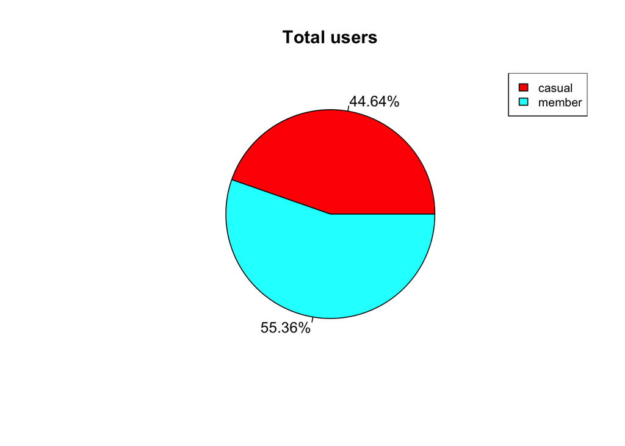

```r
users_count <- c(2048302, 2539802)
pie_labels <- paste0(round(100 * users_count/sum(users_count), 2), "%")
pie(users_count, labels = pie_labels, main = "Total users", col = rainbow(length(users_count)))
legend("topright", c("casual", "member"), cex = 0.8, fill = rainbow(length(users_count)))
```

#### Descriptive statistic

```r
mean(Total_2021_tripdata_V1$ride_length)
```

```
## Time difference of 21.81192 mins
```

```r
median(Total_2021_tripdata_V1$ride_length)
```

```
## Time difference of 12.2 mins
```

```r
min(Total_2021_tripdata_V1$ride_length)
```

```
## Time difference of 0.01666667 mins
```

```r
max(Total_2021_tripdata_V1$ride_length)
```

```
## Time difference of 55944.15 mins
```

##### Observations

- The average ride duration for both users is around 22 minutes
- The middle value listed is 12 mins
- The shortest ride is 0.01 (Probably I should´ve removed too short rides, but I do not have a criteria I can rely on)
- The longest ride is 55944.15 which is around 38 days.(*longest rides are made mostly by casual riders)

#### Average ride duration by usertype

```r
aggregate(Total_2021_tripdata_V1$ride_length ~ Total_2021_tripdata_V1$member_casual, FUN=mean)
```

```
##   Total_2021_tripdata_V1$member_casual Total_2021_tripdata_V1$ride_length
## 1                               casual                      32.51015 mins
## 2                               member                      13.18401 mins
```

#### Visual average ride duration by usertype

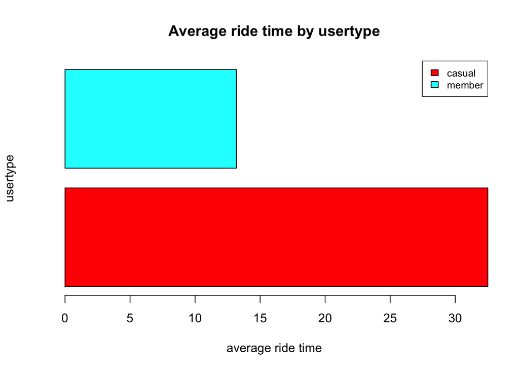

```r
average_ride_length <- c(32.51, 13.18)
label <- c("casual", "member")
barplot(average_ride_length, horiz = TRUE, xlab = "average ride time", ylab = "usertype", main = "Average ride time by usertype", col = rainbow(length(average_ride_length)))
legend("topright", c("casual", "member"), cex = 0.8, fill = rainbow(length(average_ride_length)))
```

##### Observations

–Average ride length for casual riders is 32 minutes, which is twice longer than for annual members that stand for 13 minutes.

#### The longest ride by usertype

```r
aggregate(Total_2021_tripdata_V1$ride_length ~ Total_2021_tripdata_V1$member_casual, FUN = max)
```

```
##   Total_2021_tripdata_V1$member_casual Total_2021_tripdata_V1$ride_length
## 1                               casual                     55944.150 mins
## 2                               member                      1495.633 mins
```

##### Observations

–The longest rides are made mostly by casual riders (55944.150 mins equals 38 days, 1495.633 equals 1 day).

```r
aggregate(Total_2021_tripdata_V1$ride_length ~Total_2021_tripdata_V1$member_casual, FUN = min) # criteria needed to exclude the rides that are too short
```

```
##   Total_2021_tripdata_V1$member_casual Total_2021_tripdata_V1$ride_length
## 1                               casual                    0.01666667 mins
## 2                               member                    0.01666667 mins
```

#### Median ride duration by usertype

```r
aggregate(Total_2021_tripdata_V1$ride_length ~ Total_2021_tripdata_V1$member_casual, FUN = median)
```

```
##   Total_2021_tripdata_V1$member_casual Total_2021_tripdata_V1$ride_length
## 1                               casual                     16.650000 mins
## 2                               member                      9.716667 mins
```

#### Compare total number of rides by month

```r
Total_2021_tripdata_V1%>%
  group_by(month, member_casual) %>%
  summarise(number_of_rides = n()) %>%
  arrange(month, member_casual)
```

```
## # A tibble: 24 × 3
## # Groups:   month [12]
##    month    member_casual number_of_rides
##    <chr>    <chr>                   <int>
##  1 April    casual                 120418
##  2 April    member                 177781
##  3 August   casual                 341463
##  4 August   member                 332914
##  5 December casual                  45076
##  6 December member                 131293
##  7 February casual                   8613
##  8 February member                  34381
##  9 January  casual                  14690
## 10 January  member                  68818
## # … with 14 more rows
```

```r
Total_2021_tripdata_V1$month <- ordered(Total_2021_tripdata_V1$month, levels=c("January", "February", "March", "April", "May", "June", "July", "August", "September", "October", "November", "December"))
```

#### Visualisation comparing total number of rides by month

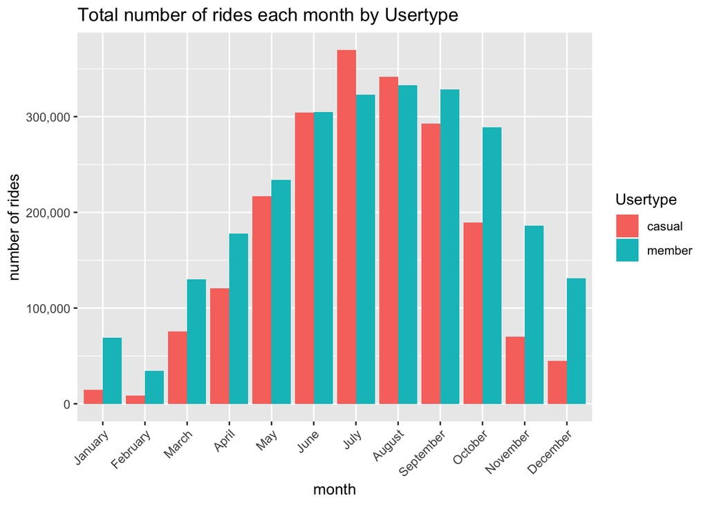

```r
Total_2021_tripdata_V1%>%
  group_by(month, member_casual) %>%
  summarise(number_of_rides = n(), .groups = 'drop') %>%
  arrange(month, member_casual) %>%
 ggplot(aes(x = month, y = number_of_rides, fill = member_casual))+
  geom_col(position = "dodge")+
  scale_y_continuous(labels = scales :: comma)+
  labs(x = "month", y = "number of rides", fill = "Usertype", title = "Total number of rides each month by Usertype")+
  guides(x = guide_axis(angle = 45))
```

##### Observation

–Bike use is growing as summer approaches for both user types. –Annual members use bikes more than casuals except for July and August when casual riders make more trips –From October to April the use of bike by casual riders decrease significantly, while for annual members the decline is more gradual –January and February -cold months, the bike use is very low –From June to September are hot months, when the bike use is very high

#### Average ride duration by month

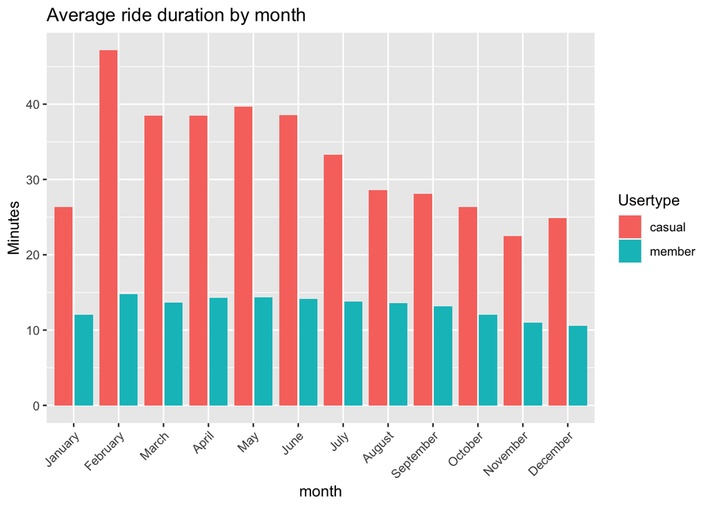

```r
  Total_2021_tripdata_V1 %>%
  group_by(month, member_casual) %>%
  summarise(average_ride_length = mean(ride_length), min(ride_length), max(ride_length), .groups = 'drop')%>%
  arrange(month, member_casual)%>%
 ggplot(aes(x = month, y = average_ride_length, fill = member_casual))+
  geom_col(position = "dodge2")+
  labs(x = "month", y = "Minutes", fill = "Usertype", title = "Average ride duration by month")+
guides(x = guide_axis(angle = 45))
```

```r
Total_2021_tripdata_V1$day_of_week <- ordered(Total_2021_tripdata_V1$day_of_week, levels=c("Sunday", "Monday", "Tuesday", "Wednesday", "Thursday", "Friday", "Saturday"))
```

#### Compare total number of rides by weekday

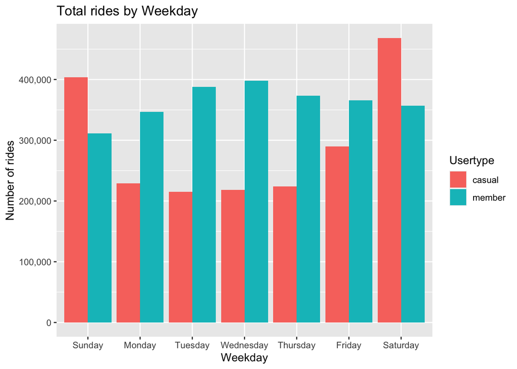

```r
Total_2021_tripdata_V1 %>%
  group_by(day_of_week, member_casual) %>%
  summarise(number_of_rides = n(), .groups = 'drop') %>%
  arrange(day_of_week, member_casual) %>%
  ggplot(aes(x = day_of_week, y = number_of_rides, fill = member_casual))+
  geom_col(position = "dodge")+
  scale_y_continuous(labels = scales :: comma)+
  labs(x = "Weekday", y = "Number of rides", fill = "Usertype", title = "Total rides by Weekday")
```

##### Observations

–From this chart, we can see that annual members are more consistent in bike use during the week with a slight increase during weekdays. –While for casual riders the bike use grows drastically during weekends. (Twice as many trips on Sat and Sun than on weekdays)

#### Compare average ride duration by weekday

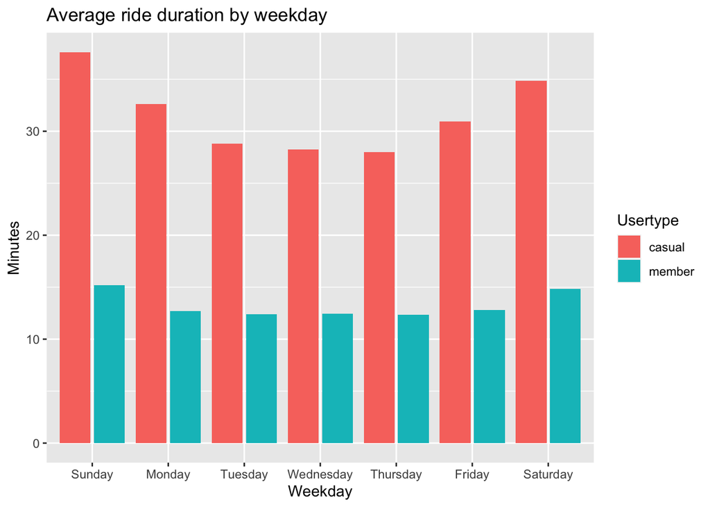

```r
  Total_2021_tripdata_V1 %>%
  group_by(day_of_week, member_casual) %>%
  summarise(average_ride_length = mean(ride_length), min(ride_length), max(ride_length), .groups = 'drop') %>%
  arrange(day_of_week, member_casual)%>%
  ggplot(aes(x = day_of_week, y = average_ride_length, fill = member_casual))+
  geom_col(position = "dodge2")+
  labs(x = "Weekday", y = "Minutes", fill = "Usertype", title = "Average ride duration by weekday")
```

#### Compare Bike type use

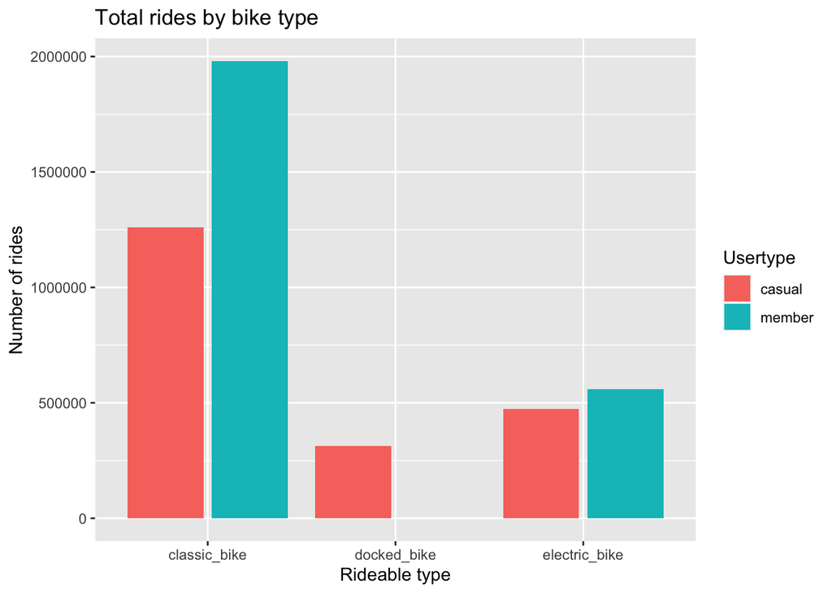

```r
Total_2021_tripdata_V1 %>%
  group_by(member_casual, rideable_type) %>%
  summarise(number_of_rides = n(), .groups = 'drop')%>%
  ggplot(aes(x = rideable_type, y = number_of_rides, fill = member_casual))+
  geom_col(position = "dodge2")+
  labs(x = "Rideable type", y = "Number of rides", fill = "Usertype", title = "Total rides by bike type")
```

##### Observations

–The most popular bike type for both usert ypes is a classic bike, second place for electric bike and some casual riders chose docked bike.

#### Add column for day hour

```r
Total_2021_tripdata_V1$ride_hour <- format(Total_2021_tripdata_V1$started_at, format = "%H")
head(Total_2021_tripdata_V1)
```

```
## # A tibble: 6 × 17
##   ride_id rideable_type started_at          ended_at            start_station_n…
##   <chr>   <chr>         <dttm>              <dttm>              <chr>
## 1 B9F734… classic_bike  2021-01-24 19:15:38 2021-01-24 19:22:51 California Ave …
## 2 457C7F… electric_bike 2021-01-23 12:57:38 2021-01-23 13:02:10 California Ave …
## 3 57C750… electric_bike 2021-01-09 15:28:04 2021-01-09 15:37:51 California Ave …
## 4 4D518C… electric_bike 2021-01-09 15:28:57 2021-01-09 15:37:54 California Ave …
## 5 9D08A3… classic_bike  2021-01-24 15:56:59 2021-01-24 16:07:08 California Ave …
## 6 49FCE1… electric_bike 2021-01-22 15:15:28 2021-01-22 15:36:01 California Ave …
## # … with 12 more variables: start_station_id <chr>, end_station_name <chr>,
## #   end_station_id <chr>, start_lat <dbl>, start_lng <dbl>, end_lat <dbl>,
## #   end_lng <dbl>, member_casual <chr>, month <ord>, day_of_week <ord>,
## #   ride_length <drtn>, ride_hour <chr>
```

```r
Total_2021_tripdata_V1$ride_hour <- ordered(Total_2021_tripdata_V1$ride_hour, levels=c("00", "01", "02", "03", "04", "05", "06", "07", "08", "09", "10", "11", "12", "13", "14", "15", "16", "17", "18", "19", "20", "21", "22", "23"))
```

#### Compare number of rides by day hour

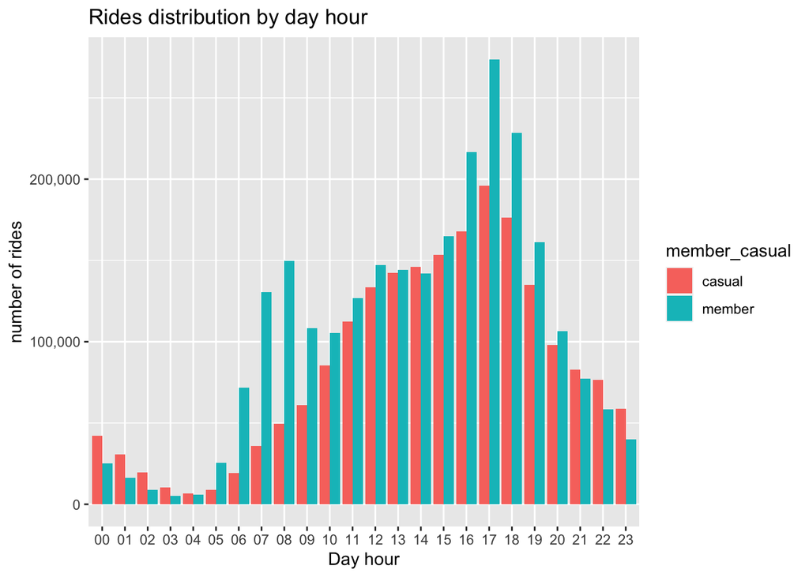

```r
Total_2021_tripdata_V1 %>%
  group_by(member_casual, ride_hour) %>%
  summarise(number_of_rides = n(), .groups = 'drop') %>%
  arrange(ride_hour)%>%
  ggplot(aes(x = ride_hour, y = number_of_rides, fill = member_casual))+
  geom_bar(position = "dodge", stat = "identity") +
  scale_y_continuous(labels = scales :: comma)+
  labs(x = "Day hour", y = "number of rides", title = "Rides distribution by day hour")
```

#### Find top 10 start stations for members

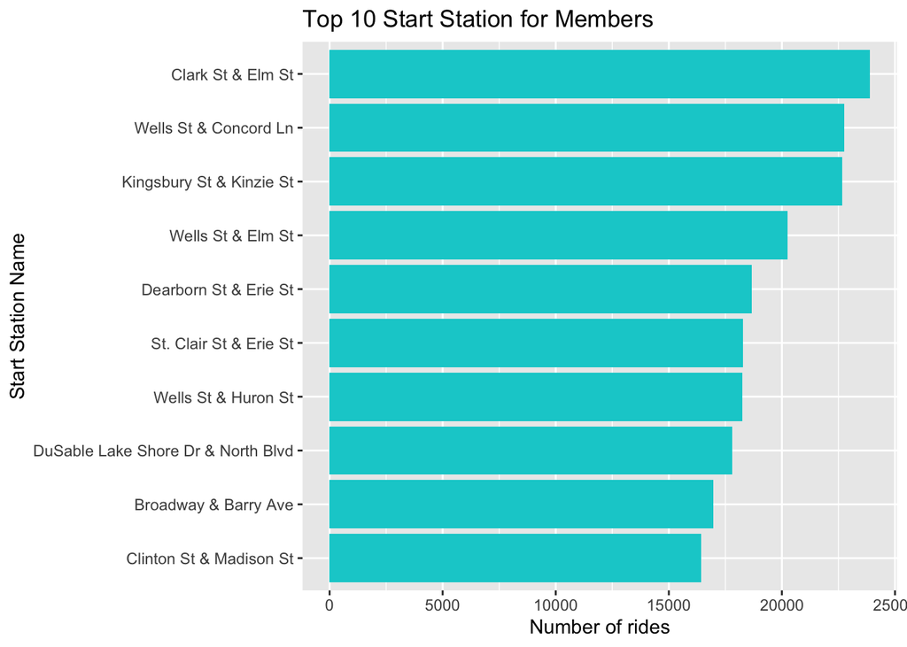

```r
Total_2021_tripdata_V1 %>%
  filter(member_casual =='member') %>%
  group_by(start_station_name) %>%
  summarise(start_station_count = n()) %>%
  arrange(desc(start_station_count)) %>%
slice(1:10)%>%
  ggplot(aes(x = start_station_count, y = reorder(start_station_name, start_station_count)))+
  geom_col(position = "dodge", fill = "darkturquoise")+
  labs(x = "Number of rides", y = "Start Station Name", title = "Top 10 Start Station for Members")
```

#### Find top 10 end stations for members

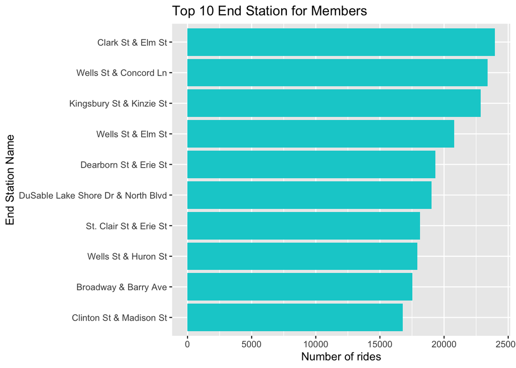

```r
Total_2021_tripdata_V1 %>%
  filter(member_casual =='member') %>%
  group_by(end_station_name) %>%
  summarise(end_station_count = n()) %>%
  arrange(desc(end_station_count)) %>%
slice(1:10)%>%
  ggplot(aes(x = end_station_count, y = reorder(end_station_name, end_station_count)))+
  geom_col(position = "dodge", fill = "darkturquoise")+
  labs(x = "Number of rides", y = "End Station Name", title = "Top 10 End Station for Members")
```

#### Find top 10 start stations for casuals

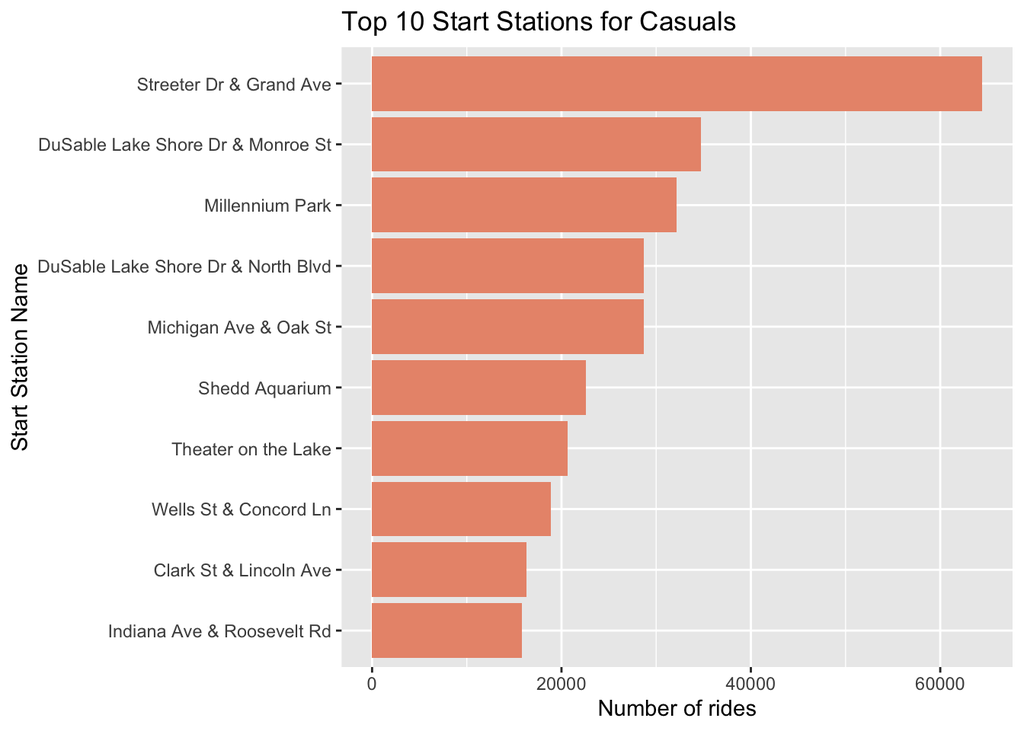

```r
Total_2021_tripdata_V1 %>%
  filter(member_casual == 'casual') %>%
  group_by(start_station_name) %>%
  summarise(start_station_count = n()) %>%
  arrange(desc(start_station_count)) %>%
  slice(1:10)%>%
  ggplot(aes(x = start_station_count, y = reorder(start_station_name, start_station_count)))+
  geom_col(position = "dodge", fill = "darksalmon")+
  labs(x = "Number of rides", y = "Start Station Name", title = "Top 10 Start Stations for Casuals")
```

#### Find top 10 end stations for casuals

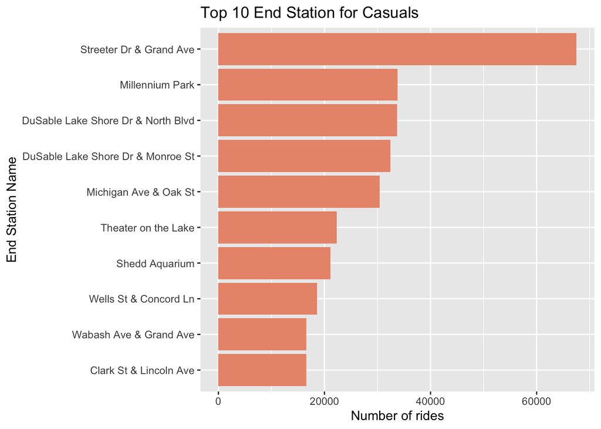

```r
Total_2021_tripdata_V1 %>%
  filter(member_casual =='casual') %>%
  group_by(end_station_name) %>%
  summarise(end_station_count = n()) %>%
  arrange(desc(end_station_count)) %>%
slice(1:10)%>%
  ggplot(aes(x = end_station_count, y = reorder(end_station_name, end_station_count)))+
  geom_col(position = "dodge", fill = "darksalmon")+
  labs(x = "Number of rides", y = "End Station Name", title = "Top 10 End Station for Casuals")
```

### Let´s create a map to see the distribution for top station by usertype

#### Create a data frame with coordinates

```r
total_trip_coordinates <- Total_2021_tripdata_V1 %>%
filter(start_lng != end_lng & start_lat != end_lat) %>%
group_by(start_lng, start_lat, end_lng, end_lat, member_casual) %>%
summarise(total_rides = n(),.groups="drop")%>%
  filter(total_rides > 100)
```

```r
glimpse(total_trip_coordinates)
```

```
## Rows: 5,587
## Columns: 6
## $ start_lng     <dbl> -87.73569, -87.72378, -87.72378, -87.72357, -87.71676, -…
## $ start_lat     <dbl> 41.96108, 41.93059, 41.93059, 41.93941, 41.91417, 41.914…
## $ end_lng       <dbl> -87.71657, -87.70786, -87.70786, -87.64754, -87.66797, -…
## $ end_lat       <dbl> 41.96115, 41.92957, 41.92957, 41.93650, 41.91461, 41.914…
## $ member_casual <chr> "member", "casual", "member", "member", "casual", "membe…
## $ total_rides   <int> 123, 124, 109, 117, 111, 479, 105, 104, 114, 116, 117, 2…
```

#### Create map image

```r
chicago <- c(left = -87.70042, bottom = 41.7908, right = -87.5548, top = 41.9901)
chicago_map <- get_stamenmap(bbox = chicago, zoom = 15, maptype = "terrain")
```

#### Visual map with top station distribution by usertype

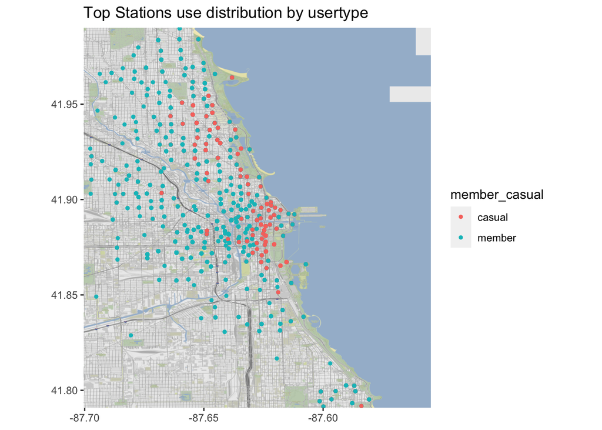

```r
ggmap(chicago_map,darken = c(0.1, "white")) +
   geom_point(total_trip_coordinates, mapping = aes(x = start_lng, y = start_lat, color = member_casual), size = 1) +
   coord_fixed(0.8) +
   labs(title = "Top Stations use distribution by usertype",x=NULL,y=NULL) +
   theme(legend.position="right")
```

##### Observations:

Most popular station for casuals are situated along the coast at the main touristic sites, while annual members are evenly distributed throughout the city and the most popular stations are located in The Near North Side the central Chicago and the most densely populated area.

Top routes for casual users are alongside central Chicago and coast from Park West to near South Side.

```r
summary_avg_ride_length <- aggregate(Total_2021_tripdata_V1$ride_length ~ Total_2021_tripdata_V1$member_casual + Total_2021_tripdata_V1$day_of_week, FUN = mean)
```

### Key Takeaways

– Bike use increases during the warmer months for both user types.

– The most popular bike type is a classic bike for both groups.

#### Annual members use bike on a regular basis commuting consistently, that motivates them to buy an annual membership.

– Have stable average ride duration during the year. Use bike during rush hours on workdays (6AM-9AM and 4PM-7PM) – Station use have a larger geographical area, most used stations are evenly spread out throughout the most densely populated area. Top 10 stations are located in The Near North Side the central Chicago. – They are active during all year and more consistent in bike use throughout a week.

#### Casual riders use bike occasionally, mostly for leisure and don´t have incentives to buy an annual membership.

– On average conduct significantly longer rides than members. – They are more active in the afternoon hours, rarely use bikes in the early morning. – Number of rides grows considerably on weekends and summer. – Top routes are alongside central Chicago and bay area from park west to near south side. Most used stations are in the center of the city, touristic sites and parks. – In winter bike use decreases considerably.

## Step 7 - Act on key findings

A successful strategy needs to provide incentives and persuade casual riders to switch into annual members.

### TOP 4 Recommendations based on key findings

1. Offer benefits that come with annual membership:
- Collaborative discounts and special offers for annual members (with leisure businesses along the Bay area and downtown: restaurants, museums, etc.)
- Rewards programs for annual members (“complete 100 km in one month and win a dinner for two” this program can incentive casuals long ride behavior)
2. Minimize possible inconvenience for the members. For example, book the bike 15 min before the ride in order to avoid arriving to the station with no bikes available, that happens during the rush hours, peak season and weekends.
3. Marketing campaigns targeting casual riders explaining health benefits of bike rides and savings with annual membership (For this we will need to collect more data on pricing plans. After completing the ride in the app show the popup message “xx km done, xxx calories burned, CO emissions reduced”.
4. Create contests for annual members. Create a community for members, so users can feel the privilege of being members.

Since the use increases during Summer months it is convenient perform marketing companies during these months. But in winter it can be useful to offer discounts for annual passes.

## Considerations for further analysis

Finding out what motivates users will help us to design more effective marketing strategy. Collect more quantitative data on demographics would provide more information about users´ differences. Also conduct a survey to get qualitative data on behavioral differences and motivation of the users. Explore more data about casuals rider´s behavior (pass types they use:single or full day), frequency of use for each rider). With these data, we can see how many rides each casual rider does during the month/year and offer a saving plans with membership that will incentive them to switch.